# Ecosystem Size Mediates the Effects of Resource Flows on Species Diversity and Ecosystem Function at Different Scales

## Parameters

```r
# --- SET UP R MARKDOWN AND GENERAL CODING RUNNING PARAMETERS --- #

set.seed(420)
start_time = Sys.time()
knitr::opts_chunk$set(message = FALSE,
                      cache = FALSE,
                      autodep = FALSE)
recompute_lengthy_analyses = FALSE
plot_model_residuals_metaecos = FALSE
```

```r
# --- SET UP PARAMETERS RELATED TO RESOURCE FLOWS --- #

disturbance_levels = c("low", "high")
n_disturbance_levels = length(disturbance_levels)

resource_flow_days = c(5, 9, 13, 17, 21, 25)
first_resource_flow = resource_flow_days[1]
```

```r
# --- SET UP SAMPLING PARAMETERS --- #

total_frames = 125
volume_recorded_μl = 34.4
time_points = 0:7
time_points_without_t0 = 1:7
time_point_names = c("t0", "t1", "t2", "t3", "t4", "t5", "t6", "t7")
sampling_days = c(0, 4, 8, 12, 16, 20, 24, 28)
first_time_point = 0
last_time_point = length(sampling_days) - 1
n_time_points = last_time_point + 1
nr_videos = c(12, 1, 1, 1, 1, 1, 2, 2) #Videos taken for each time point for each culture. At t0 we took 12 videos of the large bottle from which we started the  cultures. Write why 2 at the end.

videos_taken = data.frame(time_point = 0 : 7,
                          nr_videos = c(12, 1, 1, 1, 1, 1, 2, 2))

n_videos_taken_t0 = nr_videos[1]

time_point_day = data.frame(time_point = first_time_point:last_time_point,
                            day = sampling_days,
                            video_replicates = nr_videos)

videos_to_take_off = data.frame(ecosystem_ID = NA,
                                time_point = NA,
                                file = NA) %>%
                     add_row(ecosystem_ID = 137-110,
                             time_point = 7,
                             file = 137) %>%
                     slice(-1)

n_cultures = 110
total_number_of_video_rows = sum(nr_videos * n_cultures)
```

```r
# --- SET UP PROTIST PARAMETERS --- #

protist_species = c("Ble", "Cep", "Col", "Eug", "Eup", "Lox", "Pau", "Pca", "Spi", "Spi_te", "Tet")
protist_species_indiv_per_volume = paste0(protist_species, "_indiv_per_volume")
protist_species_indiv_per_ml = paste0(protist_species, "_indiv_per_ml")
protist_species_dominance = paste0(protist_species_indiv_per_ml, "_dominance")
protist_species_total = paste0(protist_species, "_tot_indiv")
n_protist_species = length(protist_species)
first_protist = protist_species[1]
last_protist = protist_species[n_protist_species]
species_IDD_with_13_threshold = c("Col", "Eug", "Eup", "Lox", "Pau", "Pca", "Spi_te", "Tet")
species_IDD_with_13_threshold_indiv_per_volume = paste0(species_IDD_with_13_threshold, "_indiv_per_volume")
species_IDD_with_40_threshold = c("Ble", "Cep", "Spi")
species_IDD_with_40_threshold_indiv_per_volume = paste0(species_IDD_with_40_threshold, "_indiv_per_volume")
```

```r
# --- SET UP ECOSYSTEM PARAMETERS --- #

ecosystems_to_take_off = 60 #Culture ID = 60 as it was spilled (small unconnected, high disturbance, system nr = 40)
ecosystems_info = read.csv(here("..",
                                "1_data",
                                "ecosystems_info.csv"),
                           header = TRUE) %>%
  rename(ecosystem_ID = culture_ID)

columns_ecosystems = c("time_point",
                       "day",
                       "ecosystem_ID",
                       "system_nr",
                       "disturbance",
                       "ecosystem_type",
                       "connection",
                       "ecosystem_size",
                       "ecosystem_size_ml",
                       "metaecosystem",
                       "metaecosystem_type")
columns_treatments = columns_ecosystems[!columns_ecosystems %in% c("system_nr", "ecosystem_ID")]

variables_ecosystems = c("bioarea_mm2_per_ml",
                         "bioarea_tot_mm2",
                         "indiv_per_ml",
                         "indiv_tot",
                         "species_richness",
                         "shannon",
                         "simpson",
                         "inv_simpson",
                         "evenness_pielou",
                         "median_body_area_µm2",
                         paste0(protist_species, "_indiv_per_ml"),
                         paste0(protist_species, "_tot_indiv"),
                         paste0(protist_species_indiv_per_ml, "_dominance"))
baseline_columns = paste0("baseline_", variables_ecosystems)

ecosystem_types_ordered = c("Small connected to large",
                        "Small connected to small",
                        "Small unconnected",
                        "Medium connected to medium",
                        "Medium unconnected",
                        "Large connected to small",
                        "Large connected to large",
                        "Large unconnected")

treatments_and_controls = data.frame(treatment = c("Small connected to small",
                                                   "Small connected to large",
                                                   "Medium connected to medium",
                                                   "Large connected to large",
                                                   "Large connected to small"),
                                     control = c("Small unconnected",
                                                 "Small unconnected",
                                                 "Medium unconnected",
                                                 "Large unconnected",
                                                 "Large unconnected"))

n_treatments = length(unique(treatments_and_controls$treatment))
n_controls = length(unique(treatments_and_controls$control))
n_replicates = 5
n_ecosystem_types = 8
```

```r
# --- SET UP SIZE CLASSES PARAMETERS --- #

n_size_classes = 12
columns_classes = c(columns_ecosystems,
                    "size_class_n",
                    "mean_class_area_µm2")
```

```r
# --- SET UP META-ECOSYSTEM PARAMETERS --- #

metaecosystems_to_take_off = ecosystems_info %>%
  filter(ecosystem_ID %in% ecosystems_to_take_off) %>%
  pull(system_nr) %>%
  unique

system_nr_metaecosystems = ecosystems_info %>%
  filter(metaecosystem == "yes") %>%
  pull(system_nr) %>%
  unique

n_metaecosystems = length(system_nr_metaecosystems)

variables_metaecos = c("total_metaecosystem_bioarea_mm2",
                       "jaccard_index",
                       "bray_curtis",
                       "beta_spatial_turnover",
                       "beta_nestedness",
                       "beta_total",
                       "metaecosystem_richness")

metaecosystem_types_ordered = c("Small-Small meta-ecosystem",
                                "Medium-Medium meta-ecosystem",
                                "Medium-Medium unconnected",
                                "Large-Large meta-ecosystem",
                                "Small-Large meta-ecosystem",
                                "Small-Large unconnected")

metaecosystem_type_selected = c("Medium-Medium",
                                "Small-Large")
```

Name of the axes per response variable.

```r
# --- SET UP AXES LABELS PARAMETERS --- #

axis_names = data.frame(variable = NA,
                        axis_name= NA) %>%
  add_row(variable = "day", axis_name = "Time (day)") %>%
  add_row(variable = "ecosystem_size_ml", axis_name = "Patch size (ml)") %>%
  add_row(variable = "log_size_class", axis_name = "Log size (μm2)") %>%
  add_row(variable = "class_indiv_per_µl", axis_name = "Density (ind/ml)") %>%
  add_row(variable = "bioarea_mm2_per_ml", axis_name = "Biomass (mm2/ml)") %>%
  add_row(variable = "sqrt_bioarea_mm2_per_ml", axis_name = "Sqrt Biomass (mm2/ml)") %>%
  add_row(variable = "bioarea_mm2_per_ml_d", axis_name = "Bioamass ES") %>%
  add_row(variable = "bioarea_tot", axis_name = "Total Biomass (mm2)") %>%
  add_row(variable = "total_metaecosystem_bioarea_mm2", axis_name = "Total Biomass (mm2)") %>%
  add_row(variable = "species_richness", axis_name = "Species Richness") %>%
  add_row(variable = "species_richness_d", axis_name = "Species Richness ES") %>%
  add_row(variable = "mean_richness", axis_name = "Mean α-Diversity (Shannon)") %>%
  add_row(variable = "mean_shannon", axis_name = "Mean α-Diversity (Shannon)") %>%
  add_row(variable = "shannon", axis_name = "Biodiversity (Shannon)") %>%
  add_row(variable = "sqrt_shannon", axis_name = "Sqrt Biodiversity (Shannon)") %>%
  add_row(variable = "shannon_d", axis_name = "Biodiversity ES (Shannon ES)") %>%
  add_row(variable = "bray_curtis", axis_name = "β-Diversity (Bray-Curtis)") %>%
  add_row(variable = "beta_spatial_turnover", axis_name = "Turn over (Simpson pair-wise dissimilarity)") %>%
  add_row(variable = "beta_nestedness", axis_name = "Nestedness (nestedness-fraction of Sorensen)") %>%
  add_row(variable = "beta_total", axis_name = "Tot β-Diversity (Sorensen)") %>%
  add_row(variable = "metaecosystem_richness", axis_name = "γ-Diversity (Species Richness)") %>%
  add_row(variable = "indiv_per_ml", axis_name = "Abundance (ind/ml)") %>%
  add_row(variable = "indiv_per_ml_d", axis_name = "Abundance ES") %>%
  add_row(variable = "median_body_area_µm2", axis_name = "Median Body Size (µm²)") %>%
  add_row(variable = "median_body_area_µm2_d", axis_name = "Median Body Size ES") %>%
  add_row(variable = "Ble_indiv_per_ml", axis_name = "Ble Density (ind/ml)") %>%
  add_row(variable = "Cep_indiv_per_ml", axis_name = "Cep Density (ind/ml)") %>%
  add_row(variable = "Col_indiv_per_ml", axis_name = "Col Density (ind/ml)") %>%
  add_row(variable = "Eug_indiv_per_ml", axis_name = "Eug Density (ind/ml)") %>%
  add_row(variable = "Eup_indiv_per_ml", axis_name = "Eup Density (ind/ml)") %>%
  add_row(variable = "Lox_indiv_per_ml", axis_name = "Lox Density (ind/ml)") %>%
  add_row(variable = "Pau_indiv_per_ml", axis_name = "Pau Density (ind/ml)") %>%
  add_row(variable = "Pca_indiv_per_ml", axis_name = "Pca Density (ind/ml)") %>%
  add_row(variable = "Spi_indiv_per_ml", axis_name = "Spi Density (ind/ml)") %>%
  add_row(variable = "Spi_te_indiv_per_ml", axis_name = "Spi te Density (ind/ml)") %>%
  add_row(variable = "Tet_indiv_per_ml", axis_name = "Tet Density (ind/ml)") %>%
  add_row(variable = "photo_hetero_ratio", axis_name = "Photosynthetisers-Heterotrops Ratio") %>%
  add_row(variable = "sqrt_photo_hetero_ratio", axis_name = "Sqrt Photosynthetisers-Heterotrops Ratio") %>%
  add_row(variable = "Ble_indiv_per_ml_d", axis_name = "Ble Density ES") %>%
  add_row(variable = "Cep_indiv_per_ml_d", axis_name = "Cep Density ES") %>%
  add_row(variable = "Col_indiv_per_ml_d", axis_name = "Col Density ES") %>%
  add_row(variable = "Eug_indiv_per_ml_d", axis_name = "Eug Density ES") %>%
  add_row(variable = "Eup_indiv_per_ml_d", axis_name = "Eup Density ES") %>%
  add_row(variable = "Lox_indiv_per_ml_d", axis_name = "Lox Density ES") %>%
  add_row(variable = "Pau_indiv_per_ml_d", axis_name = "Pau Density ES") %>%
  add_row(variable = "Pca_indiv_per_ml_d", axis_name = "Pca Density ES") %>%
  add_row(variable = "Spi_indiv_per_ml_d", axis_name = "Spi Density ES") %>%
  add_row(variable = "Spi_te_indiv_per_ml_d", axis_name = "Spi te Density ES") %>%
  add_row(variable = "Tet_indiv_per_ml_d", axis_name = "Tet Density ES") %>%
  add_row(variable = "Ble_indiv_per_ml_dominance", axis_name = "Ble Dominance (%)") %>%
  add_row(variable = "Cep_indiv_per_ml_dominance", axis_name = "Cep Dominance (%)") %>%
  add_row(variable = "Col_indiv_per_ml_dominance", axis_name = "Col Dominance (%)") %>%
  add_row(variable = "Eug_indiv_per_ml_dominance", axis_name = "Eug Dominance (%)") %>%
  add_row(variable = "Eup_indiv_per_ml_dominance", axis_name = "Eup Dominance (%)") %>%
  add_row(variable = "Lox_indiv_per_ml_dominance", axis_name = "Lox Dominance (%)") %>%
  add_row(variable = "Pau_indiv_per_ml_dominance", axis_name = "Pau Dominance (%)") %>%
  add_row(variable = "Pca_indiv_per_ml_dominance", axis_name = "Pca Dominance (%)") %>%
  add_row(variable = "Spi_indiv_per_ml_dominance", axis_name = "Spi Dominance (%)") %>%
  add_row(variable = "Spi_te_indiv_per_ml_dominance", axis_name = "Spi te Dominance (%)") %>%
  add_row(variable = "Tet_indiv_per_ml_dominance", axis_name = "Tet Dominance (%)") %>%
  add_row(variable = "Ble_indiv_per_ml_dominance_d", axis_name = "Ble Dominance ES") %>%
  add_row(variable = "Cep_indiv_per_ml_dominance_d", axis_name = "Cep Dominance ES") %>%
  add_row(variable = "Col_indiv_per_ml_dominance_d", axis_name = "Col Dominance ES") %>%
  add_row(variable = "Eug_indiv_per_ml_dominance_d", axis_name = "Eug Dominance ES") %>%
  add_row(variable = "Eup_indiv_per_ml_dominance_d", axis_name = "Eup Dominance ES") %>%
  add_row(variable = "Lox_indiv_per_ml_dominance_d", axis_name = "Lox Dominance ES") %>%
  add_row(variable = "Pau_indiv_per_ml_dominance_d", axis_name = "Pau Dominance ES") %>%
  add_row(variable = "Pca_indiv_per_ml_dominance_d", axis_name = "Pca Dominance ES") %>%
  add_row(variable = "Sp_indiv_per_mli_dominance_d", axis_name = "Spi Dominance ES") %>%
  add_row(variable = "Spi_te_indiv_per_ml_dominance_d", axis_name = "Spi te Dominance ES") %>%
  add_row(variable = "Tet_indiv_per_ml_dominance_d", axis_name = "Tet Dominance ES") %>%
  add_row(variable = "dominance", axis_name = "Dominance (%)") %>%
  add_row(variable = "log_abundance", axis_name = "Log Abundance + 1 (ind/mm²)") %>%
  add_row(variable = "abundance_hedges_d", axis_name = "Density ES") %>%
  add_row(variable = "beta_diversity_from_unconnected", axis_name = "Divergence from unconnected") %>%
  add_row(variable = "beta_diversity_from_previous_time", axis_name = "Temporal Divergence") %>%
  add_row(variable = "beta_diversity_from_previous_time_d", axis_name = "Temporal Divergence ES") %>%
  add_row(variable = "evenness_pielou", axis_name = "Evenness") %>%
  add_row(variable = "evenness_pielou_d", axis_name = "Evenness ES") %>%
  slice(-1)
```

```r
# --- SET UP COLOUR AND LINE TYPER PER ECOSYSTEM/META-ECOSYSTEM PARAMETERS --- #

treatment_colours = c("Small" = "#feb24c",
                      "Medium" = "#1b7837",
                      "Large" = "#3182bd",
                      "Small-Small" = "#fc9272",
                      "Large-Large" = "#67000d",
                      "Small-Large" = "#762a83",
                      "Medium-Medium" = "#1b7837",
                      "symmetric" = "#1b7837",
                      "asymmetric" = "#762a83")

treatment_colours_paper = c("symmetric" = "#1b7837",
                            "asymmetric" = "#762a83")

treatment_linetype_paper = c("connected" = "solid",
                             "unconnected" = "dashed")

treatment_linetype = c("connected to small" = "solid",
                       "connected to medium" = "dashed",
                       "connected to large" = "longdash",
                       "connected" = "solid",
                       "unconnected" = "dotted")
```

```r
# --- SET UP PLOTTING PARAMETERS --- #

figures_height_rmd_output = 7

legend_position = "top"
legend_width_cm = 2
size_legend = 12
size_x_axis = 13
size_y_axis = size_x_axis
boxplot_width = 2
dodging = 0.5
width_errorbar = 0.2
dodging_error_bar = 0.5

treatment_lines_linewidth = 1
treatment_points_size = 2.5

resource_flow_line_type = "solid"
resource_flow_line_colour = "#d9d9d9"
resource_flow_line_width = 0.3

zero_line_colour = "grey"
zero_line_line_type = "dotted"
zero_line_line_width = 0.5
zero_line_ES_line_type = "dotted"
zero_line_ES_colour = "grey"
zero_line_ES_line_width = 1

ggarrange_margin_top = 0
ggarrange_margin_bottom = 0
ggarrange_margin_left = 0
ggarrange_margin_right = 0

paper_width = 17.3
paper_height = 20
paper_units = "cm"
paper_res = 600
paper_y_axis_size = 9
paper_labels_size = 9

presentation_figure_size = 15
presentation_figure_width = 30
presentation_figure_height = 22
presentation_legend_size = 20
presentation_x_axis_size = 22
presentation_y_axis_size = presentation_x_axis_size
presentation_axes_size = 12
presentation_treatment_points_size = 5
presentation_treatment_linewidth = 2
presentation_figure_units = "cm"
presentation_figure_res = 600

grey_background_xmin = -Inf
grey_background_xmax = 7.5
grey_background_ymin = -Inf
grey_background_ymax = Inf
grey_background_fill = "#f0f0f0"
grey_background_alpha = 0.03
grey_background_color = "transparent"
```

```r
# --- SET UP MODELLING PARAMETERS --- #

time_point_of_baselines = 1
time_points_with_water_addtion = 3:7
time_points_model = 2:7
```

## Data

### Produce data from the videos

To create the data in this repository I had to analyse the videos I took of the ecosystems. Videos are not included in the repository as they are too heavy (~ 500 GB). Below is the code I used for each time point.

```r
# Clear workspace
rm(list = ls())

# Set working directory
setwd("/media/mendel-himself/ID_061_Ema2/PatchSizePilot/t0")

# Load required libraries
# library(devtools)
# install_github("femoerman/bemovi", ref="master")
library(bemovi)
library(parallel)
library(doParallel)
library(foreach)

# Define memory allocation parameters (in MB)
memory.alloc <- 240000           # Total memory allocated
memory.per.identifier <- 40000   # Memory per identifier
memory.per.linker <- 5000        # Memory per linker
memory.per.overlay <- 60000      # Memory per overlay

# Set paths for tools and particle linker
tools.path <- "/home/mendel-himself/bemovi_tools/" # Path to tools folder
to.particlelinker <- tools.path

# Set directories and file names
to.data <- paste(getwd(), "/", sep = "")
video.description.folder <- "0_video_description/"
video.description.file <- "video_description.txt"
raw.video.folder <- "1_raw/"
raw.avi.folder <- "1a_raw_avi/"
metadata.folder <- "1b_raw_meta/"
particle.data.folder <- "2_particle_data/"
trajectory.data.folder <- "3_trajectory_data/"
temp.overlay.folder <- "4a_temp_overlays/"
overlay.folder <- "4_overlays/"
merged.data.folder <- "5_merged_data/"
ijmacs.folder <- "ijmacs/"

######################################################################
# VIDEO PARAMETERS

# Define video parameters
fps <- 25                  # Video frame rate (frames per second)
total_frames <- 125        # Total length of video (frames)
width <- 2048              # Video width (pixels)
height <- 2048             # Video height (pixels)
measured_volume <- 34.4    # Measured volume (microliters) for Leica M205 C with 1.6 fold magnification, sample height 0.5 mm and Hamamatsu Orca Flash 4
pixel_to_scale <- 4.05     # Size of a pixel (micrometers) for Leica M205 C with 1.6 fold magnification, sample height 0.5 mm and Hamamatsu Orca Flash 4
video.format <- "cxd"      # Video file format (avi, cxd, mov, tiff)
difference.lag <- 10       # Difference lag
thresholds <- c(13, 255)   # Threshold values of pixel intensity (considered a measure of pixel "whiteness") for determining if a pixel belongs to an individual rather than the background

######################################################################
# FILTERING PARAMETERS
# optimized for Perfex Pro 10 stereomicrocope with Perfex SC38800 (IDS UI-3880LE-M-GL) camera
# tested stereomicroscopes: Perfex Pro 10, Nikon SMZ1500, Leica M205 C
# tested cameras: Perfex SC38800, Canon 5D Mark III, Hamamatsu Orca Flash 4
# tested species: Tet, Col, Pau, Pca, Eug, Chi, Ble, Ceph, Lox, Spi

particle_min_size <- 10           # Minimum particle size (pixels)
particle_max_size <- 1000         # Maximum particle size (pixels)
trajectory_link_range <- 3        # Number of adjacent frames for linking particles
trajectory_displacement <- 16     # Maximum displacement of a particle between frames

# Filtering criteria
filter_min_net_disp <- 25         # Minimum net displacement (µm)
filter_min_duration <- 1          # Minimum duration (s)
filter_detection_freq <- 0.1      # Minimum detection frequency (1/s)
filter_median_step_length <- 3    # Minimum median step length (µm)

######################################################################
# VIDEO ANALYSIS

# Check if all tools are installed and set permissions
check_tools_folder(tools.path)
system(paste0("chmod a+x ", tools.path, "bftools/bf.sh"))
system(paste0("chmod a+x ", tools.path, "bftools/bfconvert"))
system(paste0("chmod a+x ", tools.path, "bftools/showinf"))

# Convert video files to compressed avi format
convert_to_avi(to.data,
               raw.video.folder,
               raw.avi.folder,
               metadata.folder,
               tools.path,
               fps,
               video.format)


# Uncomment the following lines for testing
# check_video_file_names(to.data, raw.avi.folder, video.description.folder, video.description.file)
# check_threshold_values(to.data, raw.avi.folder, ijmacs.folder, 2, difference.lag, thresholds, tools.path, memory.alloc)

# Identify particles in the video
locate_and_measure_particles(to.data,
                             raw.avi.folder,
                             particle.data.folder,
                             difference.lag,
                             min_size = particle_min_size,
                             max_size = particle_max_size,
                             thresholds = thresholds,
                             tools.path,
                             memory = memory.alloc,
                             memory.per.identifier = memory.per.identifier,
                             max.cores = detectCores() - 1)

# Link particles across frames to form trajectories
link_particles(to.data,
               particle.data.folder,
               trajectory.data.folder,
               linkrange = trajectory_link_range,
               disp = trajectory_displacement,
               start_vid = 1,
               memory = memory.alloc,
               memory_per_linkerProcess = memory.per.linker,
               raw.avi.folder,
               max.cores = detectCores() - 1,
               max_time = 1)

# Merge video description file with particle data
merge_data(to.data,
           particle.data.folder,
           trajectory.data.folder,
           video.description.folder,
           video.description.file,
           merged.data.folder)

# Load the merged data
load(paste0(to.data, merged.data.folder, "Master.RData"))

# Filter trajectory data based on defined criteria
trajectory.data.filtered <- filter_data(trajectory.data,
                                        filter_min_net_disp,
                                        filter_min_duration,
                                        filter_detection_freq,
                                        filter_median_step_length)

# Summarize trajectory data to individual-based data
morph_mvt <- summarize_trajectories(trajectory.data.filtered,
                                    calculate.median = F,
                                    write = T,
                                    to.data,
                                    merged.data.folder)

# Summarize sample level data
summarize_populations(trajectory.data.filtered,
                      morph_mvt,
                      write = T,
                      to.data,
                      merged.data.folder,
                      video.description.folder,
                      video.description.file,
                      total_frames)

# Create overlays for validation
create.subtitle.overlays(to.data,
                         traj.data = trajectory.data.filtered,
                         raw.video.folder,
                         raw.avi.folder,
                         temp.overlay.folder,
                         overlay.folder,
                         fps,
                         vid.length = total_frames / fps,
                         width,
                         height,
                         tools.path = tools.path,
                         overlay.type = "number",
                         video.format)

# Create overlays (old method)
create_overlays(traj.data = trajectory.data.filtered,
                to.data = to.data,
                merged.data.folder = merged.data.folder,
                raw.video.folder = raw.avi.folder,
                temp.overlay.folder = "4a_temp_overlays_old/",
                overlay.folder = "4_overlays_old/",
                width = width,
                height = height,
                difference.lag = difference.lag,
                type = "traj",
                predict_spec = F,
                contrast.enhancement = 1,
                IJ.path = "/home/mendel-himself/bemovi_tools",
                memory = memory.alloc,
                max.cores = detectCores() - 1,
                memory.per.overlay = memory.per.overlay)
```

### Identify species

Below is the code I used to identify species to create the data in this repository.

```r
# Clear the workspace
rm(list = ls())

# Uncomment and install required packages if not already installed
#install.packages("e1071",dependencies = T)
#install.packages("devtools",dependencies = T)
#install_github("pennekampster/bemovi", ref="master")
#library(devtools)

# Load required libraries
library(bemovi)
library(e1071)
library("here")
library("tidyverse")

# Define time points in the experiment
time_points_in_experiment = c("t0", "t1", "t2", "t3", "t4", "t5", "t6", "t7")

# Loop through each time point in the experiment
for (time_point in time_points_in_experiment) {

  # Define folder names and paths
  video.description.folder = "0_video_description/"
  video.description.file = "video_description.txt"
  merged.data.folder = "5_merged_data/"
  monocultures_folder_path = here("biomass_analysis", "training", "")
  mixed_cultures_folder_path = here("biomass_analysis", time_point, "")

  #Parameters used in the video analysis script
  fps = 25
  nsv = 5
  measured_volume = 34.4
  pixel_to_scale = 4.05
  filter_min_net_disp = 25
  filter_min_duration = 1
  filter_detection_freq = 0.1
  filter_median_step_length = 3

  # Load master dataset of mono-cultures
  load(paste0(monocultures_folder_path, merged.data.folder, "Master.RData"))
  trajectory.data_monocultures = trajectory.data
  rm(trajectory.data)

  # Filter the master data of mono-cultures using the same parameters as in the video analysis script
  trajectory.data_monocultures.filtered = filter_data(trajectory.data_monocultures,
                                                      filter_min_net_disp,
                                                      filter_min_duration,
                                                      filter_detection_freq,
                                                      filter_median_step_length)

  # Summarize trajectory data to individual-based data
  morph_mvt = summarize_trajectories(data = trajectory.data_monocultures.filtered,
                                     calculate.median = FALSE,
                                     write = TRUE,
                                     to.data = monocultures_folder_path,
                                     merged.data.folder = merged.data.folder) %>%
    mutate(comment = NULL)

  # Prepare training data by removing incomplete cases
  training_data = morph_mvt[complete.cases(morph_mvt), ]

  # Train SVM model on the training data
  svm1 = svm(
    factor(species) ~
      mean_grey +
      sd_grey +
      mean_area +
      sd_area +
      mean_perimeter +
      mean_turning +
      sd_turning +
      sd_perimeter +
      mean_major +
      sd_major +
      mean_minor +
      sd_minor +
      mean_ar +
      sd_ar +
      duration +
      max_net  +
      net_disp +
      net_speed +
      gross_disp +
      max_step +
      min_step +
      sd_step +
      sd_gross_speed +
      max_gross_speed +
      min_gross_speed ,
    data = training_data,
    probability = T,
    na.action = na.pass)

  # Generate and print confusion matrix
  confusion.matrix = table(svm1$fitted, training_data$species)
  confusion.matrix.nd = confusion.matrix
  diag(confusion.matrix.nd) = 0
  svm1$confusion = cbind(confusion.matrix,
                         class.error = rowSums(confusion.matrix.nd) / rowSums(confusion.matrix))

  print(paste("Confusion matrix of time point", time_point))
  print(svm1$confusion)

  # Extract unique species names
  species.names = unique(trajectory.data_monocultures$species)

  # Load mixed cultures dataset
  load(paste0(mixed_cultures_folder_path, merged.data.folder, "Master.RData"))
  trajectory.data_mixed = trajectory.data
  rm(trajectory.data)

  # Filter mixed cultures data using the same parameters
  trajectory.data_mixed.filtered = filter_data(trajectory.data_mixed,
                                               filter_min_net_disp,
                                               filter_min_duration,
                                               filter_detection_freq,
                                               filter_median_step_length)

  # Summarize trajectory data to individual-based data
  morph_mvt = summarize_trajectories(data = trajectory.data_mixed.filtered,
                                     calculate.median = FALSE,
                                     write = TRUE,
                                     to.data = mixed_cultures_folder_path,
                                     merged.data.folder = merged.data.folder)[, which(colnames(morph_mvt) != "Col_manual")] %>%
    mutate(comment = NULL)

  # Prepare data for prediction by removing incomplete cases
  data.to.predict = morph_mvt[complete.cases(morph_mvt),]

  # Predict species using the trained SVM model
  p.id = predict(object = svm1, data.to.predict, type = "response")
  data.to.predict$predicted_species = as.character(p.id)

  # Summarize population data
  pop.data = summarize_populations(traj.data = trajectory.data_monocultures.filtered,
                                   sum.data = morph_mvt,
                                   write = TRUE,
                                   to.data = mixed_cultures_folder_path,
                                   merged.data.folder = merged.data.folder,
                                   video.description.folder = video.description.folder,
                                   video.description.file = video.description.file,
                                   total_frame = fps * nsv)

  # Function to calculate species density
  species.density = function(sample_output,
                             indiv_predicted,
                             species_names,
                             total_frames,
                             mv = measured_volume) {
    samples = unique(indiv_predicted$file)

    sp.dens = matrix(0,
                     nrow(sample_output),
                     length(species_names))

    colnames(sp.dens) = species_names

    for (i in 1:length(samples)) {
      indiv = subset(indiv_predicted, file == samples[i])

      spec = unique(indiv$predicted_species)

      for (j in 1:length(spec)) {
        all.indiv.sp = subset(indiv,
                              predicted_species == spec[j])

        dens = sum(all.indiv.sp$N_frames) / total_frames / mv
        sp.dens[which(sample_output$file == as.character(samples[i])), which(species_names == spec[j])] = dens
      }
    }

    return(cbind(sample_output, sp.dens))

  }

  # Calculate species density for the current time point
  output = species.density(pop.data,
                           data.to.predict,
                           species.names,
                           total_frames = fps * nsv,
                           mv = measured_volume)

  # Save the species density results to a CSV file
  file_name = paste0("species_ID_", time_point, ".csv")
  write.csv(output, here("biomass_analysis", "species_ID_results", file_name))
  rm(output)

}
```

### Ecosystems information (`ecosystems_info`)

```r
# --- IMPORT ECOSYSTEM INFORMATION --- #

# Read the 'ecosystems_info.csv' file

ecosystems_info = read.csv(here("..",
                                "1_data",
                                "ecosystems_info.csv"),
                           header = TRUE) %>%

  # Rename specific columns for clarity

  rename(ecosystem_ID = culture_ID,
         ecosystem_size = patch_size,
         ecosystem_size_ml = patch_size_volume) %>%



  mutate(

    # Recode 'ecosystem_size' to descriptive factor levels

    ecosystem_size = factor(case_when(ecosystem_size == "S" ~ "Small",
                                      ecosystem_size == "M" ~ "Medium",
                                      ecosystem_size == "L" ~ "Large",
                                      TRUE ~ NA_character_),
                            levels = c("Small", "Medium", "Large")),

    # Define 'connection' based on 'eco_metaeco_type'

    connection = case_when(
           eco_metaeco_type == "S" ~ "unconnected",
           eco_metaeco_type == "M" ~ "unconnected",
           eco_metaeco_type == "L" ~ "unconnected",
           eco_metaeco_type == "S (S_S)" ~ "connected to small",
           eco_metaeco_type == "S (S_L)" ~ "connected to large",
           eco_metaeco_type == "M (M_M)" ~ "connected to medium",
           eco_metaeco_type == "L (S_L)" ~ "connected to small",
           eco_metaeco_type == "L (L_L)" ~ "connected to large"),

    # Create 'ecosystem_type' as a factor based on size and connection

    ecosystem_type = factor(paste(ecosystem_size, connection),
                                 levels = ecosystem_types_ordered),

    # Recode 'metaecosystem_type' to descriptive values

    metaecosystem_type = case_when(
           metaecosystem_type == "S_S" ~ "Small-Small",
           metaecosystem_type == "M_M" ~ "Medium-Medium",
           metaecosystem_type == "L_L" ~ "Large-Large",
           metaecosystem_type == "S_L" ~ "Small-Large",
           TRUE ~ metaecosystem_type)) %>%

  # Select only relevant columns for the final dataset

  select(ecosystem_ID,
         system_nr,
         treatment_replicate,
         disturbance,
         ecosystem_size,
         ecosystem_size_ml,
         metaecosystem,
         metaecosystem_type,
         connection,
         ecosystem_type)
```

### Dataset with individuals (ds_individuals)

In this dataset (`ds_individuals`) each row represents an individual at a time point.

```r
# --- IMPORT TIME POINT 0 --- #

# Import the individual data of t0. We considered cultures to be all the same at
# the beginning (t0). Because of this reason, we filmed only the bottles from
# which cultures were assembled. Because we want to plot also t0 for the
# different treatments, we want to assign the video of bottles to all cultures
# at t0.

ds_individuals_t0_not_elongated = read.csv(here("..",
                                                "1_data",
                                                "individuals_13_threshold",
                                                "t0.csv")) %>%

  # Rename columns

  rename(body_area_µm2 = mean_area) %>%

  # Extract numeric values from 'time_point' and 'file' columns, add day and
  # video replicate

  mutate(time_point =  as.numeric(str_extract(time_point, "\\d+")),
         day = 0,
         file =  as.numeric(str_extract(file, "\\d+")),
         video_replicate = file) %>%

  # Select relevant columns

  select(time_point,
         day,
         video_replicate,
         file,
         id,
         N_frames,
         body_area_µm2)

# Elongate 't0' dataset by replicating rows based on the number of ecosystems

ds_individuals_t0_elongated = ds_individuals_t0_not_elongated %>%
  map_dfr(.x = 1 : nrow(ecosystems_info),
          .f = ~ ds_individuals_t0_not_elongated) %>%
  arrange(id) %>% # Id refers to an individual

  # Add ecosystem_ID by repeating it across rows

  mutate(ecosystem_ID = rep(1 : nrow(ecosystems_info),
                          times = nrow(ds_individuals_t0_not_elongated))) %>%

  # Select relevant columns

  select(time_point,
         day,
         video_replicate,
         file,
         ecosystem_ID,
         id,
         N_frames,
         body_area_µm2)

# Test: Check that row count matches the expected elongated dataset size

expect_equal(nrow(ds_individuals_t0_not_elongated) * nrow(ecosystems_info),
             nrow(ds_individuals_t0_elongated))
```

```r
# --- IMPORT TIME POINTS 1 TO 7 --- #

# Initialise an empty list to store data for time points t1 to t7

ds_individuals_t1_to_t7 <- list()

# Loop over each time point (excluding t0) to import data

for (time_point_i in time_points_without_t0) {

  # Read each time point's CSV file, rename columns, and set up new columns

  ds_individuals_t1_to_t7[[time_point_i]] <- read.csv(here("..",
                                                           "1_data",
                                                           "individuals_13_threshold",
                                                           paste0("t",
                                                                  time_point_i,
                                                                  ".csv"))) %>%

    # Rename columns

    rename(ecosystem_ID = culture_ID,
           body_area_µm2 = mean_area) %>%
    mutate(time_point = as.numeric(str_extract(time_point, "\\d+")),
           day = time_point_day$day[time_point_day$time_point == time_point_i], # Map day based on time_point
           file = as.numeric(str_extract(file, "\\d+")),
           video_replicate = ceiling(file / n_cultures)) # Group files into video replicates
}

# Combine all imported time points (excluding t0) into a single data frame

ds_individuals_t1_to_t7 <- ds_individuals_t1_to_t7 %>%
  bind_rows() %>%

  # Select relevant columns for the final dataset

  select(time_point,
         day,
         video_replicate,
         file,
         ecosystem_ID,
         id,
         N_frames,
         body_area_µm2)
```

```r
# --- CREATE DS_INDIVIDUALS --- #

# Bind time points 0 with time points 1 to 7 and add ecosystem information

ds_individuals = rbind(ds_individuals_t0_elongated,
                       ds_individuals_t1_to_t7) %>%
  left_join(ecosystems_info,
            by = "ecosystem_ID") %>%

  # Take off problematic videos & ecosystems

  filter(!(time_point %in% videos_to_take_off$time_point & file %in% videos_to_take_off$file),
         !ecosystem_ID %in% ecosystems_to_take_off) %>%

  # Select relevant columns

  select(disturbance,
         time_point,
         day,
         video_replicate,
         ecosystem_ID,
         system_nr,
         file,
         ecosystem_size,
         ecosystem_size_ml,
         metaecosystem,
         metaecosystem_type,
         body_area_µm2,
         N_frames)
```

### Dataset with ecosystems (`ds_ecosystems`)

In this dataset (`ds_ecosystems`) each row represents an ecosystem at a time point.

```r
# ---  IMPORT TIME POINT 0 --- #

# Initialize an empty list to store elongated datasets for each video at time
# point 0

ds_ecosystems_t0_elongated <- list()

# Import t0 ecosystem level information - biomass and individuals

ds_ecosystems_t0 = read.csv(here("..",
                                 "1_data",
                                 "ecosystems_13_threshold",
                                 "t0.csv")) %>%
  mutate(time_point =  as.numeric(str_extract(time_point, "\\d+")),
         day = 0,
         video_replicate = file) %>%
  select(time_point,
         day,
         video_replicate,
         file,
         bioarea_per_volume,
         indiv_per_volume)

# Import t0 ecosystem level information - species indiv/µl (threshold 13)

species_ID_13_threshold_t0 = read.csv(here("..",
                                           "1_data",
                                           "species_ID_13_threshold",
                                           paste0("t0.csv"))) %>%
  rename(Ble_indiv_per_volume = Ble,
         Cep_indiv_per_volume = Cep,
         Col_indiv_per_volume = Col,
         Eug_indiv_per_volume = Eug,
         Eup_indiv_per_volume = Eup,
         Lox_indiv_per_volume = Lox,
         Pau_indiv_per_volume = Pau,
         Pca_indiv_per_volume = Pca,
         Spi_indiv_per_volume = Spi,
         Spi_te_indiv_per_volume = Spi_te,
         Tet_indiv_per_volume = Tet) %>%
  select(file,
         all_of(species_IDD_with_13_threshold_indiv_per_volume))

# Import t0 ecosystem level information - species indiv/µl (threshold 40)

species_ID_40_threshold_t0 = read.csv(here("..",
                                           "1_data",
                                           "species_ID_40_threshold",
                                           paste0("t0.csv"))) %>%
  rename(Ble_indiv_per_volume = Ble,
         Cep_indiv_per_volume = Cep,
         Col_indiv_per_volume = Col,
         Eug_indiv_per_volume = Eug,
         Eup_indiv_per_volume = Eup,
         Lox_indiv_per_volume = Lox,
         Pau_indiv_per_volume = Pau,
         Pca_indiv_per_volume = Pca,
         Spi_indiv_per_volume = Spi,
         Spi_te_indiv_per_volume = Spi_te,
         Tet_indiv_per_volume = Tet) %>%
  select(file,
         all_of(species_IDD_with_40_threshold_indiv_per_volume))

# Combine biomass and species data

ds_ecosystems_t0 = ds_ecosystems_t0 %>%
  left_join(species_ID_13_threshold_t0,
            by = "file") %>%
  left_join(species_ID_40_threshold_t0,
            by = "file") %>%
  mutate(file =  as.numeric(str_extract(file, "\\d+")))

# Elongate data for each video taken at time point 0

for (video_i in 1:n_videos_taken_t0) {

  # Filter the original dataset to select data for the current video

  single_video = ds_ecosystems_t0 %>%
    filter(file == video_i)

  # Elongate current video's data with ecosystem info and assign time point
  # and day

  ds_ecosystems_t0_elongated[[video_i]] = ecosystems_info %>%
    mutate(
      time_point = 0,
      day = 0,
      file = single_video$file,
      video_replicate = single_video$video_replicate,
      bioarea_per_volume = single_video$bioarea_per_volume,
      indiv_per_volume = single_video$indiv_per_volume,
      Ble_indiv_per_volume = single_video$Ble_indiv_per_volume,
      Cep_indiv_per_volume = single_video$Cep_indiv_per_volume,
      Col_indiv_per_volume = single_video$Col_indiv_per_volume,
      Eug_indiv_per_volume = single_video$Eug_indiv_per_volume,
      Eup_indiv_per_volume = single_video$Eup_indiv_per_volume,
      Lox_indiv_per_volume = single_video$Lox_indiv_per_volume,
      Pau_indiv_per_volume = single_video$Pau_indiv_per_volume,
      Pca_indiv_per_volume = single_video$Pca_indiv_per_volume,
      Spi_indiv_per_volume = single_video$Spi_indiv_per_volume,
      Spi_te_indiv_per_volume = single_video$Spi_te_indiv_per_volume,
      Tet_indiv_per_volume = single_video$Tet_indiv_per_volume
    )
}

# Combine all elongated datasets into one data frame

ds_ecosystems_t0 = ds_ecosystems_t0_elongated %>%

  # Combine all videos data

  bind_rows() %>%

  # Select relevant columns

  select(file,
         time_point,
         day,
         ecosystem_ID,
         video_replicate,
         bioarea_per_volume,
         indiv_per_volume,
         all_of(protist_species_indiv_per_volume))

# Test: Verify the number of rows matches expected dataset size

expect_equal(nrow(ds_ecosystems_t0),
             sum(n_videos_taken_t0 * n_cultures))
```

```r
# ---  IMPORT TIME POINTS 1 TO 7 --- #

# Initialize an empty list to store data for time points t1 to t7

ds_ecosystems_t1_to_t7 = list()

# Loop through each time point, excluding t0

for (time_point_i in time_points_without_t0) {

  # Import ecosystem-level data (biomass and individuals) for the current time
  # point

  ds_ecosystems_t1_to_t7[[time_point_i]] = read.csv(here("..",
                                                         "1_data",
                                                         "ecosystems_13_threshold",
                                                         paste0("t",
                                                                time_point_i,
                                                                ".csv"))) %>%
    arrange(file) %>%
    rename(ecosystem_ID = culture_ID) %>%
    mutate(video_replicate = rep(1 : time_point_day$video_replicates[time_point_i+1],
                                 each = n_cultures),
           day = time_point_day$day[time_point_day$time_point == time_point_i]) %>%
    select(file,
           time_point,
           day,
           video_replicate,
           file,
           ecosystem_ID,
           bioarea_per_volume,
           indiv_per_volume)

  # Import species data (indiv/µL) at threshold 13 for the current time point

  species_ID_13_threshold = read.csv(here("..",
                                          "1_data",
                                          "species_ID_13_threshold",
                                          paste0("t", time_point_i, ".csv"))) %>%
    rename(Ble_indiv_per_volume = Ble,
           Cep_indiv_per_volume = Cep,
           Col_indiv_per_volume = Col,
           Eug_indiv_per_volume = Eug,
           Eup_indiv_per_volume = Eup,
           Lox_indiv_per_volume = Lox,
           Pau_indiv_per_volume = Pau,
           Pca_indiv_per_volume = Pca,
           Spi_indiv_per_volume = Spi,
           Spi_te_indiv_per_volume = Spi_te,
           Tet_indiv_per_volume = Tet) %>%
    select(file,
           all_of(species_IDD_with_13_threshold_indiv_per_volume))

  # Import species data (indiv/µL) at threshold 40 for the current time point

  species_ID_40_threshold = read.csv(here("..",
                                          "1_data",
                                          "species_ID_40_threshold",
                                          paste0("t", time_point_i, ".csv"))) %>%
    rename(Ble_indiv_per_volume = Ble,
           Cep_indiv_per_volume = Cep,
           Col_indiv_per_volume = Col,
           Eug_indiv_per_volume = Eug,
           Eup_indiv_per_volume = Eup,
           Lox_indiv_per_volume = Lox,
           Pau_indiv_per_volume = Pau,
           Pca_indiv_per_volume = Pca,
           Spi_indiv_per_volume = Spi,
           Spi_te_indiv_per_volume = Spi_te,
           Tet_indiv_per_volume = Tet) %>%
    select(file,
           all_of(species_IDD_with_40_threshold_indiv_per_volume))

  # Merge species data with ecosystem data for the current time point

  ds_ecosystems_t1_to_t7[[time_point_i]] = ds_ecosystems_t1_to_t7[[time_point_i]] %>%
    left_join(species_ID_13_threshold,
                by = "file") %>%
    left_join(species_ID_40_threshold,
                by = "file")

}

# Combine all datasets for time points t1 to t7 into a single data frame

ds_ecosystems_t1_to_t7 = ds_ecosystems_t1_to_t7 %>%
  bind_rows()
```

```r
# ---  BIND TIME POITNS AND CACLULATE ECOSYSTEM-LEVEL INFORMATION --- #

ds_ecosystems =

  # Bind time points

  rbind(ds_ecosystems_t0,
        ds_ecosystems_t1_to_t7) %>%

  # Add ecosystem information

  left_join(ecosystems_info,
            by = "ecosystem_ID") %>%

  # Extract numerical values

  mutate(time_point =  as.numeric(str_extract(time_point, "\\d+")),
         file =  as.numeric(str_extract(file, "\\d+"))) %>%

  # Change from the word volume to the word μL

  rename(bioarea_µm2_per_μL = bioarea_per_volume) %>%
  rename_all( ~ gsub("volume", "μL", .)) %>%

  # Change units of measurements to ml

  mutate(bioarea_µm2_per_ml = bioarea_µm2_per_μL * 10^3,
         bioarea_mm2_per_ml = bioarea_µm2_per_ml * 10^(-6),
         Ble_indiv_per_ml = Ble_indiv_per_μL * 10^3,
         Cep_indiv_per_ml = Cep_indiv_per_μL * 10^3,
         Col_indiv_per_ml = Col_indiv_per_μL * 10^3,
         Eug_indiv_per_ml = Eug_indiv_per_μL * 10^3,
         Eup_indiv_per_ml = Eup_indiv_per_μL * 10^3,
         Lox_indiv_per_ml = Lox_indiv_per_μL * 10^3,
         Pau_indiv_per_ml = Pau_indiv_per_μL * 10^3,
         Pca_indiv_per_ml = Pca_indiv_per_μL * 10^3,
         Spi_indiv_per_ml = Spi_indiv_per_μL * 10^3,
         Spi_te_indiv_per_ml = Spi_te_indiv_per_μL * 10^3,
         Tet_indiv_per_ml = Tet_indiv_per_μL * 10^3) %>%

  # Take off problematic videos

  filter(!(time_point %in% videos_to_take_off$time_point &
           file %in% videos_to_take_off$file)) %>%

  # Take off problematic ecosystems

  filter(!ecosystem_ID %in% ecosystems_to_take_off) %>%

  # Average videos

  group_by(across(all_of(columns_ecosystems))) %>%
  summarise(across(contains("_per_ml"), mean),
            across(contains("_tot"), mean)) %>%
  ungroup() %>%

  # Calculate ecosystem-level metrics

  mutate(indiv_per_ml = !!rlang::parse_expr(paste(protist_species_indiv_per_ml,
                                                  collapse = " + ")),

         bioarea_tot_mm2 = bioarea_mm2_per_ml * ecosystem_size_ml,

         indiv_tot = indiv_per_ml * ecosystem_size_ml,

         Ble_tot_indiv = Ble_indiv_per_ml * ecosystem_size_ml,
         Cep_tot_indiv = Cep_indiv_per_ml * ecosystem_size_ml,
         Col_tot_indiv = Col_indiv_per_ml * ecosystem_size_ml,
         Eug_tot_indiv = Eug_indiv_per_ml * ecosystem_size_ml,
         Eup_tot_indiv = Eup_indiv_per_ml * ecosystem_size_ml,
         Lox_tot_indiv = Lox_indiv_per_ml * ecosystem_size_ml,
         Pau_tot_indiv = Pau_indiv_per_ml * ecosystem_size_ml,
         Pca_tot_indiv = Pca_indiv_per_ml * ecosystem_size_ml,
         Spi_tot_indiv = Spi_indiv_per_ml * ecosystem_size_ml,
         Spi_te_tot_indiv = Spi_te_indiv_per_ml * ecosystem_size_ml,
         Tet_tot_indiv = Tet_indiv_per_ml * ecosystem_size_ml,

         across(.cols = all_of(protist_species_indiv_per_ml),
                .fns = list(dominance = ~ (. / indiv_per_ml) * 100),
                .names = "{col}_dominance"),

         photo_hetero_ratio  = (Eug_indiv_per_ml + Eup_indiv_per_ml) /
                             (Ble_indiv_per_ml +
                              Cep_indiv_per_ml +
                              Col_indiv_per_ml +
                              Lox_indiv_per_ml +
                              Pau_indiv_per_ml +
                              Pca_indiv_per_ml +
                              Spi_indiv_per_ml +
                              Spi_te_indiv_per_ml +
                              Tet_indiv_per_ml))

# Add biodiversity metrics

ds_ecosystems = calculate.alpha.diversity()

# Add median body size

ds_median_body_size = ds_individuals %>%
  group_by(time_point,
           ecosystem_ID,
           file) %>%
  summarise(median_body_area_µm2 = median(body_area_µm2)) %>%
  group_by(time_point,
           ecosystem_ID) %>%
  summarise(median_body_area_µm2 = mean(median_body_area_µm2))

ds_ecosystems = full_join(ds_ecosystems,
                          ds_median_body_size)
```

### Dataset with meta-ecosystems (`ds_metaecosystems`)

In this dataset (`ds_metaecosystems`) each row represents a meta-ecosystem at a time point.

```r
# --- FIND IDS OF UNCONNECTED ECOSYSTEMS --- #

ID_unconnected_S_low = ds_ecosystems %>%
  filter(ecosystem_type == "Small unconnected",
         disturbance == "low") %>%
  pull(ecosystem_ID) %>%
  unique()

ID_unconnected_M_low = ds_ecosystems %>%
  filter(ecosystem_type == "Medium unconnected",
         disturbance == "low") %>%
  pull(ecosystem_ID) %>%
  unique()

ID_unconnected_L_low = ds_ecosystems %>%
  filter(ecosystem_type == "Large unconnected",
         disturbance == "low") %>%
  pull(ecosystem_ID) %>%
  unique()

ID_unconnected_S_high = ds_ecosystems %>%
  filter(ecosystem_type == "Small unconnected",
         disturbance == "high") %>%
  pull(ecosystem_ID) %>%
  unique()

ID_unconnected_M_high = ds_ecosystems %>%
  filter(ecosystem_type == "Medium unconnected",
         disturbance == "high") %>%
  pull(ecosystem_ID) %>%
  unique()

ID_unconnected_L_high = ds_ecosystems %>%
  filter(ecosystem_type == "Large unconnected",
         disturbance == "high") %>%
  pull(ecosystem_ID) %>%
  unique()
```

```r
# --- FIND COMBINATIONS OF ECOSYSTEMS TO CREATE UNCONNECTED META-ECOSYSTEMS --- #

combinations_S_and_L_low = crossing(ID_unconnected_S_low,
                                    ID_unconnected_L_low) %>%
                            mutate(disturbance = "low",
                                   metaecosystem_type = "Small-Large",
                                   connection = "unconnected") %>%
                            rename(ID_first_ecosystem = ID_unconnected_S_low,
                                   ID_second_ecosystem = ID_unconnected_L_low) %>%
                            select(disturbance,
                                   metaecosystem_type,
                                   connection,
                                   ID_first_ecosystem,
                                   ID_second_ecosystem)

combinations_S_and_L_high = crossing(ID_unconnected_S_high,
                                     ID_unconnected_L_high) %>%
                            mutate(disturbance = "high",
                                   metaecosystem_type = "Small-Large",
                                   connection = "unconnected") %>%
                            rename(ID_first_ecosystem = ID_unconnected_S_high,
                                   ID_second_ecosystem = ID_unconnected_L_high) %>%
                            select(disturbance,
                                   metaecosystem_type,
                                   connection,
                                   ID_first_ecosystem,
                                   ID_second_ecosystem)

combinations_M_and_M_low = combinat::combn(ID_unconnected_M_low,
                                           m = 2) %>%
                            t() %>%
                            as.data.frame() %>%
                            rename(ID_first_ecosystem = V1,
                                   ID_second_ecosystem = V2) %>%
                            mutate(disturbance = "low",
                                   metaecosystem_type = "Medium-Medium",
                                   connection = "unconnected") %>%
                            select(disturbance,
                                   metaecosystem_type,
                                   connection,
                                   ID_first_ecosystem,
                                   ID_second_ecosystem)

combinations_M_and_M_high = combinat::combn(ID_unconnected_M_high,
                                            m = 2) %>%
                            t() %>%
                            as.data.frame() %>%
                            rename(ID_first_ecosystem = V1,
                                   ID_second_ecosystem = V2) %>%
                            mutate(disturbance = "high",
                                   metaecosystem_type = "Medium-Medium",
                                   connection = "unconnected") %>%
                            select(disturbance,
                                   metaecosystem_type,
                                   connection,
                                   ID_first_ecosystem,
                                   ID_second_ecosystem)

# Test code

expect_equal(nrow(combinations_S_and_L_low),
             length(ID_unconnected_S_low) * length(ID_unconnected_L_low))
expect_equal(nrow(combinations_S_and_L_high),
             length(ID_unconnected_S_high) * length(ID_unconnected_L_high))
expect_equal(nrow(combinations_M_and_M_low),
             sum(seq(length(ID_unconnected_M_low) - 1)))
expect_equal(nrow(combinations_M_and_M_high),
             sum(seq(length(ID_unconnected_M_high) - 1)))
```

```r
# --- BIND ECOSYSTEM COMBINATIONS --- #

combinations_unconnected_metaeco = rbind(combinations_S_and_L_low,
                                         combinations_S_and_L_high,
                                         combinations_M_and_M_low,
                                         combinations_M_and_M_high) %>%
  mutate(system_nr = 1001:(1000 + nrow(.))) %>%
  select(system_nr,
         disturbance,
         metaecosystem_type,
         connection,
         ID_first_ecosystem,
         ID_second_ecosystem)
```

```r
# --- FIND COMBINATIONS OF ECOSYSTEMS TO CREATE CONNECTED META-ECOSYSTEMS --- #

combinations_connected_metaeco = ds_ecosystems %>%
  filter(time_point == 0,
         metaecosystem == "yes") %>%
  select(system_nr,
         disturbance,
         metaecosystem_type,
         ecosystem_ID) %>%
  group_by(system_nr,
           disturbance,
           metaecosystem_type) %>%
  summarise(ID_first_ecosystem = (mean(ecosystem_ID) - 0.5),
            ID_second_ecosystem = (mean(ecosystem_ID) + 0.5)) %>%
  mutate(connection = "connected") %>%
  as.data.frame()
```

```r
# --- BIND COMBINATIONS OF ECOSYSTEMS TO CREATE UNCONNECTED & CONNECTED META-ECOSYSTEMS --- #

ecos_combin = rbind(combinations_unconnected_metaeco,
                               combinations_connected_metaeco) %>%
  mutate(ecosystems_combined = paste0(ID_first_ecosystem, "|", ID_second_ecosystem))

n_ecosystems_combinations = nrow(ecos_combin)

# Test code

expect_equal(nrow(ecos_combin),
             nrow(combinations_unconnected_metaeco) + nrow(combinations_connected_metaeco))
```

```r
# --- CREATE SETS FOR SMALL-LARGE UNCONNECTED META-ECOSYSTEMS --- #
# Create sets for Small-Large unconnected meta-ecosystems where in each set a
# small and a large ecosystems are paired differently (keep the small ecosystems
# on the same order and perform permutations on the large ecosystems)

# Initialize a list to store combinations for each disturbance level

SL_unconn_ecos_comb_sets <- vector("list",
                                  length(disturbance_levels))

# Loop over each disturbance level

for (disturbance_i in 1:length(disturbance_levels)) {

  # Extract unique IDs for small and large unconnected ecosystems for the
  # current disturbance level

  ID_small_ecosystems = ds_ecosystems %>%
    filter(disturbance == disturbance_levels[disturbance_i],
           ecosystem_type == "Small unconnected") %>%
    pull(ecosystem_ID) %>%
    unique()

  ID_large_ecosystems = ds_ecosystems %>%
    filter(disturbance == disturbance_levels[disturbance_i],
           ecosystem_type == "Large unconnected") %>%
    pull(ecosystem_ID) %>%
    unique()

  #Force small and large ecosystems vectors to have the same length

  length_difference <- length(ID_small_ecosystems) - length(ID_large_ecosystems)

  # Ensure small and large ecosystems vectors have the same length

  if (length_difference > 0) {

    ID_large_ecosystems = c(ID_large_ecosystems,
                       rep("Patch taken off",
                           times = abs(length(ID_small_ecosystems) -
                                       length(ID_large_ecosystems))))

    } else if (length_difference < 0) {

    ID_small_ecosystems = c(ID_small_ecosystems,
                         rep("Patch taken off",
                             times = abs(length(ID_large_ecosystems) -
                                         length(ID_small_ecosystems))))
    }

  # Generate permutations of large ecosystem IDs

  permutations_large = permn(ID_large_ecosystems)

  # Create a dataframe for combinations of small and large ecosystems

  SL_unconn_ecos_comb_sets[[disturbance_i]] = data.frame(
    disturbance = disturbance_levels[disturbance_i],
    metaecosystem_type = "Small-Large",
    connection = "unconnected",
    ID_first_ecosystem = rep(ID_small_ecosystems,
                             times = length(permutations_large)),
    ID_second_ecosystem = unlist(permutations_large),
    set = rep(1 : length(permutations_large),
              each = length(ID_small_ecosystems)))

  # Verify the number of rows in the dataframe matches the expected count

  expect_equal(nrow(SL_unconn_ecos_comb_sets[[disturbance_i]]),
               length(ID_small_ecosystems) * length(permutations_large))

  # Filter out any rows with "Patch taken off" and convert IDs to double

  SL_unconn_ecos_comb_sets[[disturbance_i]] = SL_unconn_ecos_comb_sets[[disturbance_i]] %>%
    filter(!ID_first_ecosystem == "Patch taken off",
           !ID_second_ecosystem == "Patch taken off") %>%
    mutate(ID_first_ecosystem = as.double(ID_first_ecosystem),
           ID_second_ecosystem = as.double(ID_second_ecosystem)) %>%
    full_join(ecos_combin %>%
                filter(disturbance == disturbance_levels[disturbance_i],
                       metaecosystem_type == "Small-Large",
                       connection == "unconnected"))

}

# Store the combinations before binding into a single dataframe

SL_unconn_ecos_comb_sets_before_binding = SL_unconn_ecos_comb_sets

# Bind all the sets into a single dataframe

SL_unconn_ecos_comb_sets = SL_unconn_ecos_comb_sets %>%
  bind_rows()

# Test: check that the total number of rows matches the expected sum of
# combinations

expect_equal(nrow(SL_unconn_ecos_comb_sets),
             nrow(SL_unconn_ecos_comb_sets_before_binding[[1]]) +
                  nrow(SL_unconn_ecos_comb_sets_before_binding[[2]]))

# Test: verify that the unique system numbers in the final dataframe match
# those in the original combinations

expect_equal(length(SL_unconn_ecos_comb_sets %>%
                      pull(system_nr) %>%
                      unique()),
             length(ecos_combin %>%
                      filter(metaecosystem_type == "Small-Large",
                             connection == "unconnected") %>%
                      pull(system_nr) %>%
                      unique()))
```

```r
# --- CREATE SETS FOR MEDIUM-MEDIUM UNCONNECTED META-ECOSYSTEMS --- #

# Create sets for Medium-Medium unconnected meta-ecosystems where in each set
# two different medium ecosystems are paired. To do so, initialise
# MM_unconn_ecos_comb_sets. Assign 10^4 rows to each matrix so that we have
# enough rows not to run out of them when we try to assign values to them.
# Assign 4 columns which will include ecosystem_ID of the first system, second
# ecosystem_ID of the fist system, ecosystem_ID of the second system, and second
# ecosystem_ID of the second system.

# Initialize an empty list to store combinations for each disturbance level

MM_unconn_ecos_comb_sets = list()

# Assign an empty matrix with 10^4 rows and 4 columns for each disturbance level

for(disturbance_i in 1:length(disturbance_levels)){

  MM_unconn_ecos_comb_sets[[disturbance_i]] <- matrix(nrow = 10 ^ 4,
                                                 ncol = 4)

}

# Loop over each disturbance level to generate combinations of medium ecosystems

for (disturbance_i in 1:length(disturbance_levels)) {

  # Extract unique IDs for medium unconnected ecosystems for the current
  # disturbance level

  ID_medium_ecosystems = ds_ecosystems %>%
    filter(disturbance == disturbance_levels[disturbance_i],
           ecosystem_type == "Medium unconnected") %>%
    pull(ecosystem_ID) %>%
    unique()

  # Generate all combinations of two medium ecosystems

  MM_unconnected_systems = combn(ID_medium_ecosystems,
                              2) %>%
    t()

  matrix_row = 0

  # Loop through combinations to find valid pairs of unconnected ecosystems

  for (first_system_i in 1:nrow(MM_unconnected_systems)) {

    # Identify the first ecosystem

    first_system = MM_unconnected_systems[first_system_i, ]

    for (second_system_i in 1:nrow(MM_unconnected_systems)) {

      # Identify the second ecosystem

      second_system = MM_unconnected_systems[second_system_i, ]

      # Check for shared elements between the two systems

      shared_elements_among_systems = intersect(first_system,
                                                second_system)

      # If there are no shared elements, store the combination

      if (length(shared_elements_among_systems) == 0) {

        matrix_row = matrix_row + 1

        #Make first and second system into a set

        MM_unconn_ecos_comb_sets[[disturbance_i]][matrix_row,] = c(first_system,
                                                                   second_system)

      }
    }
  }

  # Convert the matrix to a dataframe and remove NA rows

  MM_unconn_ecos_comb_sets[[disturbance_i]] = MM_unconn_ecos_comb_sets[[disturbance_i]] %>%
    as.data.frame() %>%
    drop_na()

  # Test: ensure no duplicate IDs in the combinations

  expect_equal(MM_unconn_ecos_comb_sets[[disturbance_i]] %>%
                 filter(V1 == V2 |
                        V1 == V3 |
                        V1 == V4 |
                        V2 == V3 |
                        V2 == V4 |
                        V3 == V4) %>%
                 nrow(),
               0)

  # Reorder the dataset with all the ecosystem combinations

  MM_unconn_ecos_comb_sets_reordered = data.frame(ID_first_ecosystem = NA,
                                          ID_second_ecosystem = NA,
                                          set = NA)

  for (set_input in 1:nrow(MM_unconn_ecos_comb_sets[[disturbance_i]])) {
    MM_unconn_ecos_comb_sets_reordered = MM_unconn_ecos_comb_sets_reordered %>%
      add_row(ID_first_ecosystem = MM_unconn_ecos_comb_sets[[disturbance_i]][set_input, 1],
              ID_second_ecosystem = MM_unconn_ecos_comb_sets[[disturbance_i]][set_input, 2],
              set = set_input) %>%
      add_row(ID_first_ecosystem = MM_unconn_ecos_comb_sets[[disturbance_i]][set_input, 3],
              ID_second_ecosystem = MM_unconn_ecos_comb_sets[[disturbance_i]][set_input, 4],
              set = set_input)
  }

  #Add to a list

  MM_unconn_ecos_comb_sets[[disturbance_i]] = MM_unconn_ecos_comb_sets_reordered %>%
    drop_na() %>%
    mutate(disturbance = disturbance_levels[disturbance_i],
           metaecosystem_type = "Medium-Medium",
           connection = "unconnected")

  #Add system nr

  ID_combinations_MM_unconnected = ecos_combin %>%
    filter(disturbance == disturbance_levels[disturbance_i],
           metaecosystem_type == "Medium-Medium",
           connection == "unconnected")

  MM_unconn_ecos_comb_sets[[disturbance_i]] = full_join(MM_unconn_ecos_comb_sets[[disturbance_i]],
                                                   ID_combinations_MM_unconnected)

}

# Bind all sets of medium-medium unconnected combinations into a single
# dataframe

MM_unconn_ecos_comb_sets = MM_unconn_ecos_comb_sets %>%
  bind_rows()

# Test

expect_equal(length(MM_unconn_ecos_comb_sets %>%
                      pull(system_nr) %>%
                      unique()),
             length(ecos_combin %>%
                      filter(metaecosystem_type == "Medium-Medium",
                             connection == "unconnected") %>%
                      pull(system_nr) %>%
                      unique()))
```

```r
# --- BIND SL AND MM UNCONNECTED META-ECOSYSTEMS SETS --- #

ecos_combin_unconn_sets = rbind(SL_unconn_ecos_comb_sets,
                                MM_unconn_ecos_comb_sets) %>%
  select(disturbance,
         metaecosystem_type,
         connection,
         set,
         system_nr,
         ID_first_ecosystem,
         ID_second_ecosystem)
```

```r
# --- FIND SETS OF SETS --- #

# Find the number of combinations of SL & MM low or high disturbance

n_SL_low_sets = ecos_combin_unconn_sets %>%
  filter(metaecosystem_type == "Small-Large",
         disturbance == "low") %>%
  pull(set) %>%
  max()

n_SL_high_sets = ecos_combin_unconn_sets %>%
  filter(metaecosystem_type == "Small-Large",
         disturbance == "high") %>%
  pull(set) %>%
  max()

n_MM_low_sets = ecos_combin_unconn_sets %>%
  filter(metaecosystem_type == "Medium-Medium",
         disturbance == "low") %>%
  pull(set) %>%
  max()

n_MM_high_sets = ecos_combin_unconn_sets %>%
  filter(metaecosystem_type == "Medium-Medium",
         disturbance == "high") %>%
  pull(set) %>%
  max()

# Find combinations of sets

ecos_combin_unconn_sets_of_sets <- expand.grid(set_SL_low = 1:n_SL_low_sets,
                                            set_SL_high = 1:n_SL_high_sets,
                                            set_MM_low = 1:n_MM_low_sets,
                                            set_MM_high = 1:n_MM_high_sets)
```

```r
# --- COMPUTE META-ECOSYSTEMS FOR EACH TIME POINT --- #

# Set parameters and initialise

ds_metaecosystems = list()
row_i = 0

# Compute meta-ecosystems

for (combination_i in 1:n_ecosystems_combinations) {
  for (time_point_selected in time_points) {

    row_i = row_i + 1

    current_day = sampling_days[time_point_selected + 1]
    current_system_nr = ecos_combin[combination_i, ]$system_nr
    current_combination = ecos_combin[combination_i, ]$ecosystems_combined
    current_disturbance = ecos_combin[combination_i, ]$disturbance
    current_metaeco_type = ecos_combin[combination_i, ]$metaecosystem_type
    current_connection = ecos_combin[combination_i, ]$connection
    current_IDs = c(ecos_combin[combination_i, ]$ID_first_ecosystem,
                    ecos_combin[combination_i, ]$ID_second_ecosystem)

    if (current_system_nr %in% metaecosystems_to_take_off)
      next

    if (current_IDs[1] == current_IDs[2])
      next

    species_vector_two_ecosystems = ds_ecosystems %>%
      filter(time_point == time_point_selected,
             ecosystem_ID %in% current_IDs) %>%
      ungroup() %>%
      select(all_of(protist_species_indiv_per_ml))

    absence_presence_two_ecosystems <-
      ifelse(species_vector_two_ecosystems > 0, 1, 0)

    #Alpha diversity: Shannon (mean between the two ecosystems)

    shannon_ecosystem_1 = diversity(species_vector_two_ecosystems[1, ],
                                    index = "shannon")
    shannon_ecosystem_2 = diversity(species_vector_two_ecosystems[2, ],
                                    index = "shannon")
    shannon_value = (shannon_ecosystem_1 + shannon_ecosystem_2) / 2

    #Alpha diversity: Species richness (mean between the two ecosystems)

    richness_ecosystem_1 = specnumber(species_vector_two_ecosystems[1, ])
    richness_ecosystem_2 = specnumber(species_vector_two_ecosystems[2, ])
    mean_richness_value = (richness_ecosystem_1 + richness_ecosystem_2) / 2

    #Beta diversity: Jaccard

    jaccard_index_value = vegdist(species_vector_two_ecosystems,
                                  method = "jaccard") %>%
      as.numeric()

    #Beta diversity: Bray Curtis

    bray_curtis_value = vegdist(species_vector_two_ecosystems,
                                method = "bray") %>%
      as.numeric()

    #Beta diversity: partitioning of beta diversity from Sorensen index into
    # turnover (Simpson pair-wise dissimilarity) and nestedness
    # (nestedness-fraction of Sorensen)

    betapart_core_object = betapart.core(absence_presence_two_ecosystems)
    beta_spatial_turnover_value = beta.pair(betapart_core_object)$beta.sim %>%
      as.double()
    beta_nestedness_value = beta.pair(betapart_core_object)$beta.sne %>%
      as.double()
    beta_total_value = beta.pair(betapart_core_object)$beta.sor %>%
      as.double()

    #Gamma diversity: Meta-ecosystem richness

    metaecosystem_richness_value = colSums(species_vector_two_ecosystems) %>%
      specnumber()

    #Put everything together

    ds_metaecosystems[[ row_i]] = ds_ecosystems %>%
      filter(ecosystem_ID %in% current_IDs,
             time_point == time_point_selected) %>%
      summarise(total_metaecosystem_bioarea_mm2 = sum(bioarea_tot_mm2),
                total_metaecosystem_Ble_indiv = sum(Ble_tot_indiv),
                total_metaecosystem_Cep_indiv = sum(Cep_tot_indiv),
                total_metaecosystem_Col_indiv = sum(Col_tot_indiv),
                total_metaecosystem_Eug_indiv = sum(Eug_tot_indiv),
                total_metaecosystem_Eup_indiv = sum(Eup_tot_indiv),
                total_metaecosystem_Lox_indiv = sum(Lox_tot_indiv),
                total_metaecosystem_Pau_indiv = sum(Pau_tot_indiv),
                total_metaecosystem_Pca_indiv = sum(Pca_tot_indiv),
                total_metaecosystem_Spi_indiv = sum(Spi_tot_indiv),
                total_metaecosystem_Spi_te_indiv = sum(Spi_te_tot_indiv),
                total_metaecosystem_Tet_indiv = sum(Tet_tot_indiv)) %>%
      mutate(system_nr = current_system_nr,
             ecosystems_combined = current_combination,
             metaecosystem_type = current_metaeco_type,
             ecosystem_size_symmetry = case_when(
               metaecosystem_type == "Small-Large" ~ "asymmetric",
               metaecosystem_type == "Medium-Medium" ~ "symmetric",
               metaecosystem_type == "Small-Small" ~ "symmetric",
               metaecosystem_type == "Large-Large" ~ "symmetric"),
             connection = current_connection,
             disturbance = current_disturbance,
             time_point = time_point_selected,
             day = current_day,
             jaccard_index = jaccard_index_value,
             bray_curtis = bray_curtis_value,
             beta_spatial_turnover = beta_spatial_turnover_value,
             beta_nestedness = beta_nestedness_value,
             beta_total = beta_total_value,
             metaecosystem_richness = metaecosystem_richness_value,
             mean_shannon = shannon_value,
             mean_richness = mean_richness_value) %>%
      ungroup() %>%
      as.data.frame() %>%
      select(time_point,
             day,
             system_nr,
             ecosystems_combined,
             disturbance,
             metaecosystem_type,
             ecosystem_size_symmetry,
             connection,
             mean_shannon,
             mean_richness,
             jaccard_index,
             bray_curtis,
             beta_spatial_turnover,
             beta_nestedness,
             beta_total,
             metaecosystem_richness,
             total_metaecosystem_bioarea_mm2,
             paste0("total_metaecosystem_", protist_species, "_indiv"))
  }
}
# Bind everything together

ds_metaecosystems = ds_metaecosystems %>%
  bind_rows()

# Test: check the number of rows are right

expect_equal(nrow(ds_metaecosystems),
             n_time_points * n_ecosystems_combinations)
```

## Meta-ecosystems analysis

```r
metaecosystem_type_selected = c("Medium-Medium", "Small-Large")
```

### α-Diversity

```r
response_variable_selected = "mean_shannon"
```

**Plot original data - means**

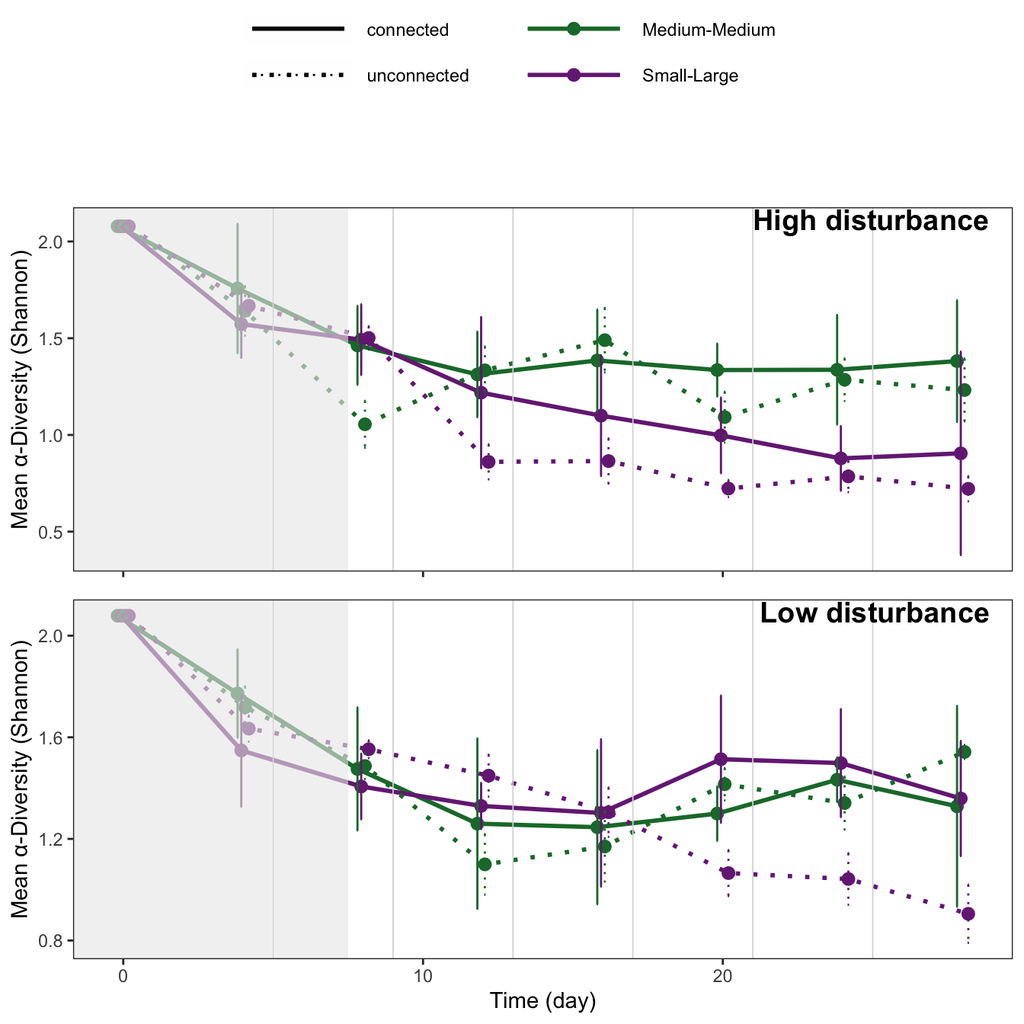

```r
# --- ORIGINAL DATA - PLOT MEAN ± 95% CI --- #

# Create plots

p1=plot.metaecos.points(ds_metaecosystems %>% filter(disturbance == "high"),
                        metaecosystem_type_selected,
                        response_variable_selected) +
  annotate("text",
           x = Inf,
           y = Inf,
           label = "High disturbance",
           hjust = 1.1,
           vjust = 1.1,
           size = 5,
           fontface = "bold") + # Adjust position and style
  theme(axis.title.x = element_blank(),  # Remove x-axis title
        axis.text.x = element_blank())  # Remove x-axis text

p2=plot.metaecos.points(ds_metaecosystems %>% filter(disturbance == "low"),
                        metaecosystem_type_selected,
                        response_variable_selected) +
  theme(legend.position = "none") +
  annotate("text",
           x = Inf,
           y = Inf,
           label = "Low disturbance",
           hjust = 1.1,
           vjust = 1.1,
           size = 5,
           fontface = "bold") # Adjust position and style

# Arrange the plots vertically

ggarrange(p1,
          p2,
          ncol = 1,
          nrow = 2,
          heights = c(0.9, 1),
          common.legend = TRUE,
          align = "v")
```

**Plot original data - single replicates**

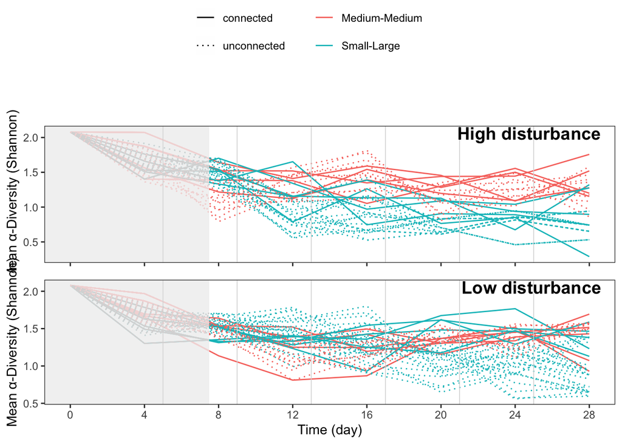

```r
# --- ORIGINAL DATA - PLOT SINGLE REPLICATES --- #

p1=plot.metaecos.replicates(ds_metaecosystems %>% filter(disturbance == "high"),
                            metaecosystem_type_selected,
                            response_variable_selected) +
  annotate("text",
           x = Inf,
           y = Inf,
           label = "High disturbance",
           hjust = 1.1,
           vjust = 1.1,
           size = 5,
           fontface = "bold") + # Adjust position and style
  theme(axis.title.x = element_blank(),  # Remove x-axis title
        axis.text.x = element_blank())  # Remove x-axis text

p2=plot.metaecos.replicates(ds_metaecosystems %>% filter(disturbance == "low"),
                            metaecosystem_type_selected,
                            response_variable_selected) +
  theme(legend.position = "none") +
  annotate("text",
           x = Inf,
           y = Inf,
           label = "Low disturbance",
           hjust = 1.1,
           vjust = 1.1,
           size = 5,
           fontface = "bold") # Adjust position and style

# Arrange the plots vertically

ggarrange(p1,
          p2,
          ncol = 1,
          nrow = 2,
          heights = c(0.9, 1),
          common.legend = TRUE,
          align = "v")
```

**Prepare data for analysis**

```r
# --- PREPARE DATA --- #

# Add baselines

baselines = ds_metaecosystems %>%
  filter(time_point == time_point_of_baselines) %>%
  select(system_nr,
         all_of(response_variable_selected)) %>%
  rename(baseline = all_of(response_variable_selected))

data_for_analysis = ds_metaecosystems %>%
  left_join(baselines)

# Filter and change level names

data_for_analysis = data_for_analysis %>%
  filter(time_point %in% time_points_model,
         metaecosystem_type %in% metaecosystem_type_selected,
         #!is.na(total_water_addition_ml),
         !is.na(!!sym(response_variable_selected))) %>%
  mutate(metaecosystem_type = case_when(metaecosystem_type == "Small-Large unconnected" ~ "SL unc",
                                        metaecosystem_type == "Medium-Medium unconnected" ~ "MM unc",
                                        metaecosystem_type == "Small-Small meta-ecosystem" ~ "SS con",
                                        metaecosystem_type == "Medium-Medium meta-ecosystem" ~ "MM con",
                                        metaecosystem_type == "Large-Large meta-ecosystem" ~ "LL con",
                                        metaecosystem_type == "Small-Large meta-ecosystem" ~ "SL con",
                                        TRUE ~ metaecosystem_type),
         type_conn = paste(metaecosystem_type, connection))
```

**Plot data for analysis means**

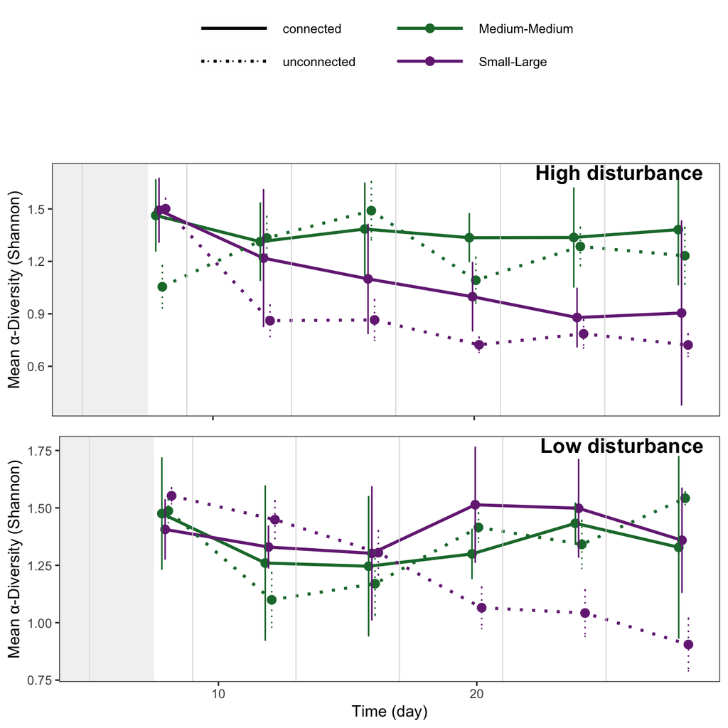

```r
# --- DATA FOR ANALYSIS - PLOT MEAN ± 95% CI OF FILTERED DATA --- #

p1=plot.metaecos.points(data_for_analysis %>% filter(disturbance == "high"),
                        metaecosystem_type_selected,
                        response_variable_selected) +
  annotate("text",
           x = Inf,
           y = Inf,
           label = "High disturbance",
           hjust = 1.1,
           vjust = 1.1,
           size = 5,
           fontface = "bold") + # Adjust position and style
  theme(axis.title.x = element_blank(),  # Remove x-axis title
        axis.text.x = element_blank())  # Remove x-axis text

p2=plot.metaecos.points(data_for_analysis %>% filter(disturbance == "low"),
                        metaecosystem_type_selected,
                        response_variable_selected) +
  theme(legend.position = "none") +
  annotate("text",
           x = Inf,
           y = Inf,
           label = "Low disturbance",
           hjust = 1.1,
           vjust = 1.1,
           size = 5,
           fontface = "bold") # Adjust position and style

# Arrange the plots vertically

ggarrange(p1,
          p2,
          ncol = 1,
          nrow = 2,
          heights = c(1, 0.7))
```

**Compute model results**

```r
# --- DEFINE MODEL FORMULA --- #

formula = paste("get(response_variable_selected) ~",
                "type_conn * disturbance * day +",
                "(day | baseline) +",
                "(day | system_nr)") %>%
  print()
```

```
## [1] "get(response_variable_selected) ~ type_conn * disturbance * day + (day | baseline) + (day | system_nr)"
```

```r
# --- FIND ECOSYSTEM COMBINATIONS FOR ANALYSIS --- #

# Set up parameters

bootstrap_iterations = 1000

# Produce random (bootstrapped) rows

random_sets_of_sets <- runif(bootstrap_iterations,
                             min = 1,
                             max = nrow(ecos_combin_unconn_sets_of_sets)) %>%
  round()

# Filter combinations according to the random rows

sets_of_sets_filtered = ecos_combin_unconn_sets_of_sets %>%
  filter(row_number() %in% random_sets_of_sets)
```

```r
# --- DEFINE WHERE TO SAVE (AND FROM WHERE TO LATER READ) THE RESULTS OF THE ANALYSIS --- #

file_path = here("..",
                 "3_results",
                 "tables",
                 paste0("results_metaeco_",
                        response_variable_selected,
                        "_",
                        bootstrap_iterations,
                        "_iterations",
                        ".csv"))
```

```r
# --- FIND MODEL STATISTICS THROUGH MULTIPLE ITERATIONS RESHUFFLING ECOSYSTEM COMBINATIONS --- #

# Set parameters and initialise

results_table = list()
failed_optimizers = 0

# Fit models

for (comb_i in 1:bootstrap_iterations) {

  # Find system numbers

  system_nr_unconn_selected = ecos_combin_unconn_sets %>%
    filter(metaecosystem_type == "Small-Large" &
           disturbance == "low" &
           set == sets_of_sets_filtered[comb_i, ]$set_SL_low |
           metaecosystem_type == "Small-Large" &
           disturbance == "high" &
           set == sets_of_sets_filtered[comb_i, ]$set_SL_high |
           metaecosystem_type == "Medium-Medium" &
           disturbance == "low" &
           set == sets_of_sets_filtered[comb_i, ]$set_MM_low |
           metaecosystem_type == "Medium-Medium" &
           disturbance == "high" &
           set == sets_of_sets_filtered[comb_i, ]$set_MM_high) %>%
    pull(system_nr)

  # Prepare data for analysis

  data_for_analysis_comb_i = data_for_analysis %>%
    filter(system_nr %in% system_nr_unconn_selected | connection == "connected")

  # Run model

  model = try.different.optimizers.metaecos(data_for_analysis_comb_i,
                                            formula)

  # If all the optimisers fail, move on to the next iteration

  if (is.null(model)) {
    cat("This model could not be fitted with any optimiser (",
        system_nr_unconn_selected,
        ") \n")

    failed_optimizers = failed_optimizers + 1

    next
  }

  # Residuals - show Q-Q plot

  # print(qqnorm(resid(model))); print(qqline(resid(model)))

  # Residuals - save Residuals vs Fitted plot

  # plot = data_for_analysis_comb_i %>%
  #     mutate(predicted = fitted(model),
  #            residuals = resid(model)) %>%
  #     ggplot(aes(x = predicted,
  #                y = residuals)) +
  #     geom_point()
  #
  # ggsave(here("3_results",
  #             "residual_plots",
  #               paste0("res_vs_fit_",
  #                      response_variable_selected,
  #                      "_combination_",
  #                      comb_i,
  #                      ".png")),
  #          plot = plot,
  #          width = 8,
  #          height = 6)

  # Set up contrasts

  emmeans_output = emmeans(model,
                           specs = ~ type_conn * day * disturbance ,
                           method = "pairwise",
                           adjust = "sidak",
                           bias.adj = TRUE,
                           lmer.df = "satterthwaite")

  summary(emmeans_output)

  zeros = rep(0, 8)
  high_MM_conn = zeros; high_MM_conn[1] = 1
  high_MM_unc = zeros; high_MM_unc[2] = 1
  high_SL_conn = zeros; high_SL_conn[3] = 1
  high_SL_unc = zeros; high_SL_unc[4] = 1
  low_MM_conn = zeros; low_MM_conn[5] = 1
  low_MM_unc = zeros; low_MM_unc[6] = 1
  low_SL_conn = zeros; low_SL_conn[7] = 1
  low_SL_unc = zeros; low_SL_unc[8] = 1

  # Save contrasts in a table

  results_table[[comb_i]] = contrast(
    emmeans_output,
    method = list("high SL_conn - SL_unc" = high_SL_conn - high_SL_unc,
                  "high MM_conn - MM_unc" = high_MM_conn - high_MM_unc,
                  "low SL_conn - SL_unc" = low_SL_conn - low_SL_unc,
                  "low MM_conn - MM_unc" = low_MM_conn - low_MM_unc)) %>%
    as.data.frame() %>%
    mutate(combination = comb_i,
           system_nr_unconnected_systems = paste(system_nr_unconn_selected, collapse = ", "))

}

# Tell how many optimizers failed

print(paste((failed_optimizers/bootstrap_iterations * 100),
            "% of combinations created models that could not be fit"))

# Bind rows within the list results_table

results_table = results_table %>%
  bind_rows()

# Save the results

write.csv(results_table,
          file = file_path,
          row.names = F)
```

```r
# --- READ THE RESULTS AFTER LENGTHY COMPUTATION --- #

results_table = read.csv(file = file_path)
```

**Show iterated results - p value distributions**

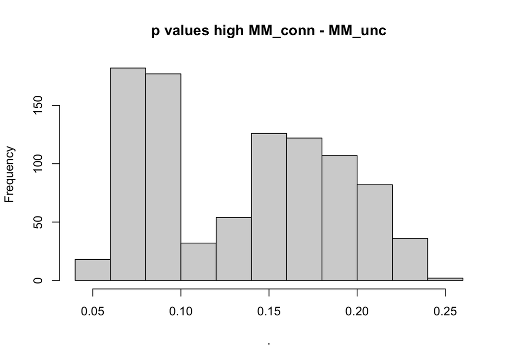

```r
# --- SHOW ITERATED RESULTS - P VALUE DISTRIBUTIONS --- #

results_table %>%
  filter(contrast == "high MM_conn - MM_unc") %>%
  pull(p.value) %>%
  hist(main = "p values high MM_conn - MM_unc")
```

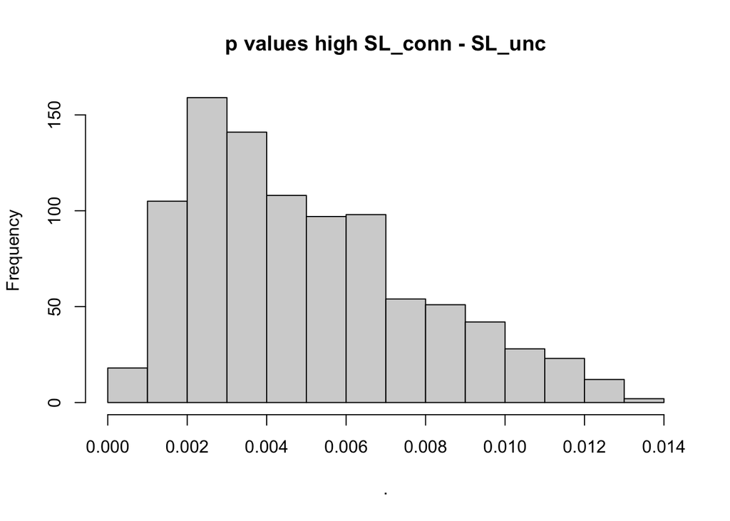

```r
results_table %>%
  filter(contrast == "high SL_conn - SL_unc") %>%
  pull(p.value) %>%
  hist(main = "p values high SL_conn - SL_unc")
```

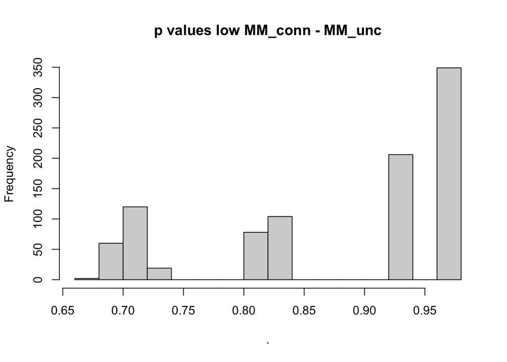

```r
results_table %>%
  filter(contrast == "low MM_conn - MM_unc") %>%
  pull(p.value) %>%
  hist(main = "p values low MM_conn - MM_unc")
```

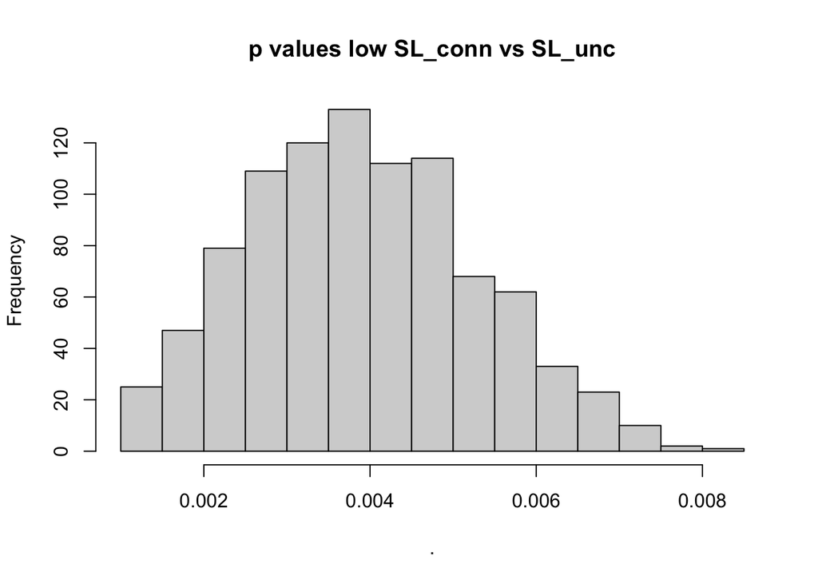

```r
results_table %>%
  filter(contrast == "low SL_conn - SL_unc") %>%
  pull(p.value) %>%
  hist(main = "p values low SL_conn vs SL_unc")
```

**Show iterated results - table with averaged values**

```r
# --- SHOW ITERATED RESULTS - TABLE WITH AVERAGED VALUES --- #

results_table %>%
  group_by(contrast) %>%
  summarise(estimate = median(estimate),
            SE = median(SE),
            df = median(df),
            t.ratio = median(t.ratio),
            p.value = median(p.value)) %>%
  as.data.frame() %>%
  mutate(estimate = round(estimate, digits = 3),
         SE = round(SE, digits = 3),
         df = round(df, digits = 3),
         t.ratio = round(t.ratio, digits = 3),
         p.value = round(p.value, digits = 3),
         evidence = "",
         evidence = ifelse(p.value > 0.1,
                           "none",
                           evidence),
         evidence = ifelse(p.value < 0.1,
                           "* weak",
                           evidence),
         evidence = ifelse(p.value < 0.05,
                           "** moderate",
                           evidence),
         evidence = ifelse(p.value < 0.01,
                           "*** strong",
                           evidence),
         evidence = ifelse(p.value < 0.001,
                           "**** very strong",
                           evidence),
         p.value = ifelse(p.value < 0.001,
                          "< 0.001",
                          p.value))
```

```
##                contrast estimate    SE    df t.ratio p.value   evidence
## 1 high MM_conn - MM_unc    0.115 0.078 37.56   1.497   0.142       none
## 2 high SL_conn - SL_unc    0.190 0.063 37.56   3.034   0.004 *** strong
## 3  low MM_conn - MM_unc   -0.003 0.078 37.56  -0.034   0.933       none
## 4  low SL_conn - SL_unc    0.182 0.059 37.56   3.075   0.004 *** strong
```

### β-Diversity

```r
response_variable_selected = "bray_curtis"
```

**Plot original data - means**

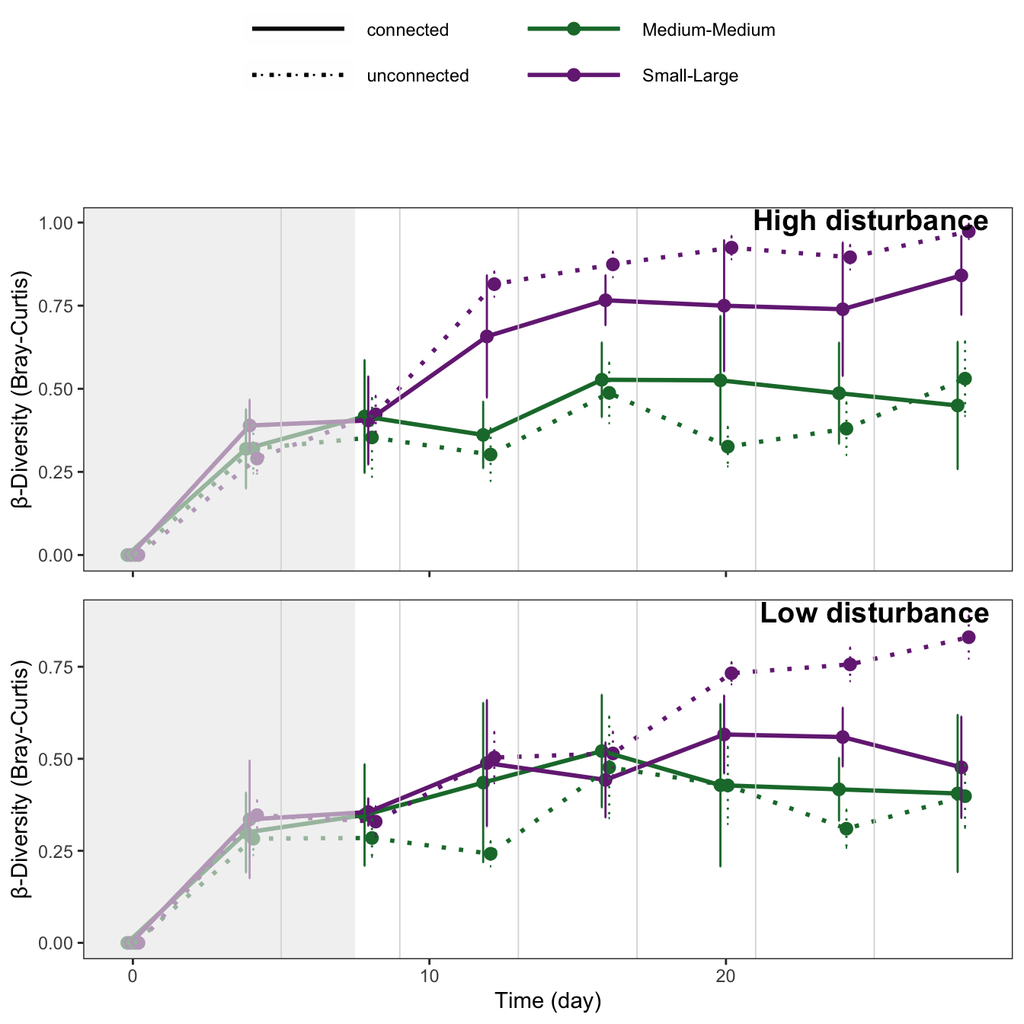

```r
# --- ORIGINAL DATA - PLOT MEAN ± 95% CI --- #

# Create plots

p1=plot.metaecos.points(ds_metaecosystems %>% filter(disturbance == "high"),
                        metaecosystem_type_selected,
                        response_variable_selected) +
  annotate("text",
           x = Inf,
           y = Inf,
           label = "High disturbance",
           hjust = 1.1,
           vjust = 1.1,
           size = 5,
           fontface = "bold") + # Adjust position and style
  theme(axis.title.x = element_blank(),  # Remove x-axis title
        axis.text.x = element_blank())  # Remove x-axis text

p2=plot.metaecos.points(ds_metaecosystems %>% filter(disturbance == "low"),
                        metaecosystem_type_selected,
                        response_variable_selected) +
  theme(legend.position = "none") +
  annotate("text",
           x = Inf,
           y = Inf,
           label = "Low disturbance",
           hjust = 1.1,
           vjust = 1.1,
           size = 5,
           fontface = "bold") # Adjust position and style

# Arrange the plots vertically

ggarrange(p1,
          p2,
          ncol = 1,
          nrow = 2,
          heights = c(0.9, 1),
          common.legend = TRUE,
          align = "v")
```

**Plot original data - single replicates**

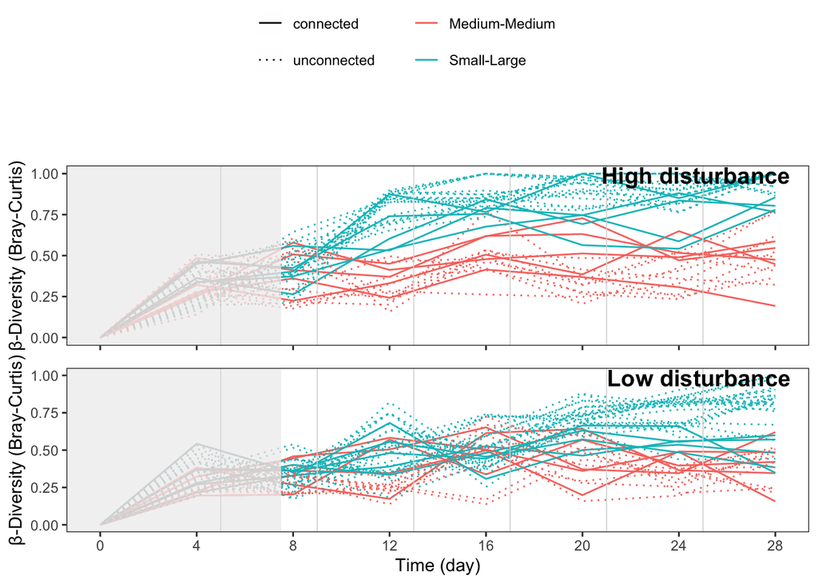

```r
# --- ORIGINAL DATA - PLOT SINGLE REPLICATES --- #

p1=plot.metaecos.replicates(ds_metaecosystems %>% filter(disturbance == "high"),
                            metaecosystem_type_selected,
                            response_variable_selected) +
  annotate("text",
           x = Inf,
           y = Inf,
           label = "High disturbance",
           hjust = 1.1,
           vjust = 1.1,
           size = 5,
           fontface = "bold") + # Adjust position and style
  theme(axis.title.x = element_blank(),  # Remove x-axis title
        axis.text.x = element_blank())  # Remove x-axis text

p2=plot.metaecos.replicates(ds_metaecosystems %>% filter(disturbance == "low"),
                            metaecosystem_type_selected,
                            response_variable_selected) +
  theme(legend.position = "none") +
  annotate("text",
           x = Inf,
           y = Inf,
           label = "Low disturbance",
           hjust = 1.1,
           vjust = 1.1,
           size = 5,
           fontface = "bold") # Adjust position and style

# Arrange the plots vertically

ggarrange(p1,
          p2,
          ncol = 1,
          nrow = 2,
          heights = c(0.9, 1),
          common.legend = TRUE,
          align = "v")
```

**Prepare data for analysis**

```r
# --- PREPARE DATA --- #

# Add baselines

baselines = ds_metaecosystems %>%
  filter(time_point == time_point_of_baselines) %>%
  select(system_nr,
         all_of(response_variable_selected)) %>%
  rename(baseline = all_of(response_variable_selected))

data_for_analysis = ds_metaecosystems %>%
  left_join(baselines)

# Filter and change level names

data_for_analysis = data_for_analysis %>%
  filter(time_point %in% time_points_model,
         metaecosystem_type %in% metaecosystem_type_selected,
         #!is.na(total_water_addition_ml),
         !is.na(!!sym(response_variable_selected))) %>%
  mutate(metaecosystem_type = case_when(metaecosystem_type == "Small-Large unconnected" ~ "SL unc",
                                        metaecosystem_type == "Medium-Medium unconnected" ~ "MM unc",
                                        metaecosystem_type == "Small-Small meta-ecosystem" ~ "SS con",
                                        metaecosystem_type == "Medium-Medium meta-ecosystem" ~ "MM con",
                                        metaecosystem_type == "Large-Large meta-ecosystem" ~ "LL con",
                                        metaecosystem_type == "Small-Large meta-ecosystem" ~ "SL con",
                                        TRUE ~ metaecosystem_type),
         type_conn = paste(metaecosystem_type, connection))
```

**Plot data for analysis means**

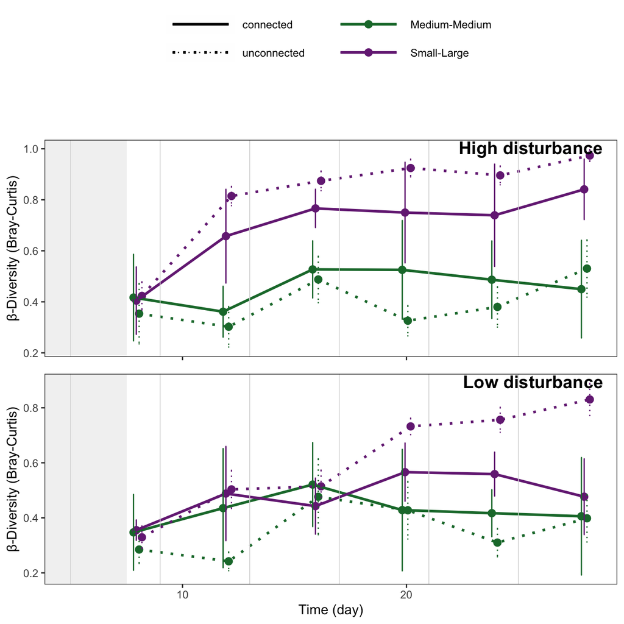

```r
# --- DATA FOR ANALYSIS - PLOT MEAN ± 95% CI OF FILTERED DATA --- #

p1=plot.metaecos.points(data_for_analysis %>% filter(disturbance == "high"),
                        metaecosystem_type_selected,
                        response_variable_selected) +
  annotate("text",
           x = Inf,
           y = Inf,
           label = "High disturbance",
           hjust = 1.1,
           vjust = 1.1,
           size = 5,
           fontface = "bold") + # Adjust position and style
  theme(axis.title.x = element_blank(),  # Remove x-axis title
        axis.text.x = element_blank())  # Remove x-axis text

p2=plot.metaecos.points(data_for_analysis %>% filter(disturbance == "low"),
                        metaecosystem_type_selected,
                        response_variable_selected) +
  theme(legend.position = "none") +
  annotate("text",
           x = Inf,
           y = Inf,
           label = "Low disturbance",
           hjust = 1.1,
           vjust = 1.1,
           size = 5,
           fontface = "bold") # Adjust position and style

# Arrange the plots vertically

ggarrange(p1,
          p2,
          ncol = 1,
          nrow = 2,
          heights = c(1, 0.7))
```

**Compute model results**

```r
# --- DEFINE MODEL FORMULA --- #

formula = paste("get(response_variable_selected) ~",
                "type_conn * disturbance * day +",
                "(day | baseline) +",
                "(day | system_nr)") %>%
  print()
```

```
## [1] "get(response_variable_selected) ~ type_conn * disturbance * day + (day | baseline) + (day | system_nr)"
```

```r
# --- FIND ECOSYSTEM COMBINATIONS FOR ANALYSIS --- #

# Set up parameters

bootstrap_iterations = 1000

# Produce random (bootstrapped) rows

random_sets_of_sets <- runif(bootstrap_iterations,
                             min = 1,
                             max = nrow(ecos_combin_unconn_sets_of_sets)) %>%
  round()

# Filter combinations according to the random rows

sets_of_sets_filtered = ecos_combin_unconn_sets_of_sets %>%
  filter(row_number() %in% random_sets_of_sets)
```

```r
# --- DEFINE WHERE TO SAVE (AND FROM WHERE TO LATER READ) THE RESULTS OF THE ANALYSIS --- #

file_path = here("..",
                 "3_results",
                 "tables",
                 paste0("results_metaeco_",
                        response_variable_selected,
                        "_",
                        bootstrap_iterations,
                        "_iterations",
                        ".csv"))
```

```r
# --- FIND MODEL STATISTICS THROUGH MULTIPLE ITERATIONS RESHUFFLING ECOSYSTEM COMBINATIONS --- #

# Set parameters and initialise

results_table = list()
failed_optimizers = 0

# Fit models

for (comb_i in 1:bootstrap_iterations) {

  # Find system numbers

  system_nr_unconn_selected = ecos_combin_unconn_sets %>%
    filter(metaecosystem_type == "Small-Large" &
           disturbance == "low" &
           set == sets_of_sets_filtered[comb_i, ]$set_SL_low |
           metaecosystem_type == "Small-Large" &
           disturbance == "high" &
           set == sets_of_sets_filtered[comb_i, ]$set_SL_high |
           metaecosystem_type == "Medium-Medium" &
           disturbance == "low" &
           set == sets_of_sets_filtered[comb_i, ]$set_MM_low |
           metaecosystem_type == "Medium-Medium" &
           disturbance == "high" &
           set == sets_of_sets_filtered[comb_i, ]$set_MM_high) %>%
    pull(system_nr)

  # Prepare data for analysis

  data_for_analysis_comb_i = data_for_analysis %>%
    filter(system_nr %in% system_nr_unconn_selected | connection == "connected")

  # Run model

  model = try.different.optimizers.metaecos(data_for_analysis_comb_i,
                                            formula)

  # If all the optimisers fail, move on to the next iteration

  if (is.null(model)) {
    cat("This model could not be fitted with any optimiser (",
        system_nr_unconn_selected,
        ") \n")

    failed_optimizers = failed_optimizers + 1

    next
  }

  # Residuals - show Q-Q plot

  # print(qqnorm(resid(model))); print(qqline(resid(model)))

  # Residuals - save Residuals vs Fitted plot

  # plot = data_for_analysis_comb_i %>%
  #     mutate(predicted = fitted(model),
  #            residuals = resid(model)) %>%
  #     ggplot(aes(x = predicted,
  #                y = residuals)) +
  #     geom_point()
  #
  # ggsave(here("3_results",
  #             "residual_plots",
  #               paste0("res_vs_fit_",
  #                      response_variable_selected,
  #                      "_combination_",
  #                      comb_i,
  #                      ".png")),
  #          plot = plot,
  #          width = 8,
  #          height = 6)

  # Set up contrasts

  emmeans_output = emmeans(model,
                           specs = ~ type_conn * day * disturbance ,
                           method = "pairwise",
                           adjust = "sidak",
                           bias.adj = TRUE,
                           lmer.df = "satterthwaite")

  summary(emmeans_output)

  zeros = rep(0, 8)
  high_MM_conn = zeros; high_MM_conn[1] = 1
  high_MM_unc = zeros; high_MM_unc[2] = 1
  high_SL_conn = zeros; high_SL_conn[3] = 1
  high_SL_unc = zeros; high_SL_unc[4] = 1
  low_MM_conn = zeros; low_MM_conn[5] = 1
  low_MM_unc = zeros; low_MM_unc[6] = 1
  low_SL_conn = zeros; low_SL_conn[7] = 1
  low_SL_unc = zeros; low_SL_unc[8] = 1

  # Save contrasts in a table

  results_table[[comb_i]] = contrast(
    emmeans_output,
    method = list("high SL_conn - SL_unc" = high_SL_conn - high_SL_unc,
                  "high MM_conn - MM_unc" = high_MM_conn - high_MM_unc,
                  "low SL_conn - SL_unc" = low_SL_conn - low_SL_unc,
                  "low MM_conn - MM_unc" = low_MM_conn - low_MM_unc)) %>%
    as.data.frame() %>%
    mutate(combination = comb_i,
           system_nr_unconnected_systems = paste(system_nr_unconn_selected, collapse = ", "))

}

# Tell how many optimizers failed

print(paste((failed_optimizers/bootstrap_iterations * 100),
            "% of combinations created models that could not be fit"))

# Bind rows within the list results_table

results_table = results_table %>%
  bind_rows()

# Save the results

write.csv(results_table,
          file = file_path,
          row.names = F)
```

```r
# --- READ THE RESULTS AFTER LENGTHY COMPUTATION --- #

results_table = read.csv(file = file_path)
```

**Show iterated results - p value distributions**

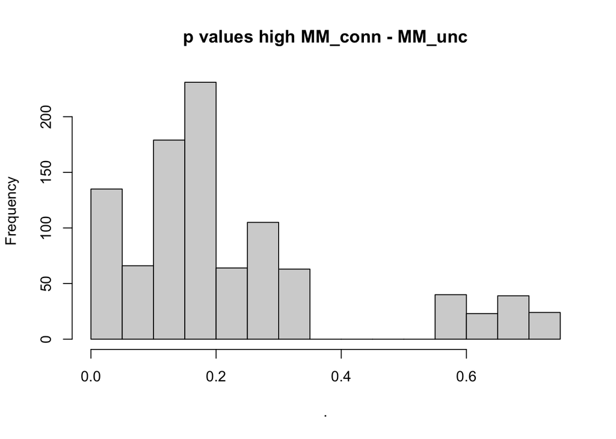

```r
# --- SHOW ITERATED RESULTS - P VALUE DISTRIBUTIONS --- #

results_table %>%
  filter(contrast == "high MM_conn - MM_unc") %>%
  pull(p.value) %>%
  hist(main = "p values high MM_conn - MM_unc")
```

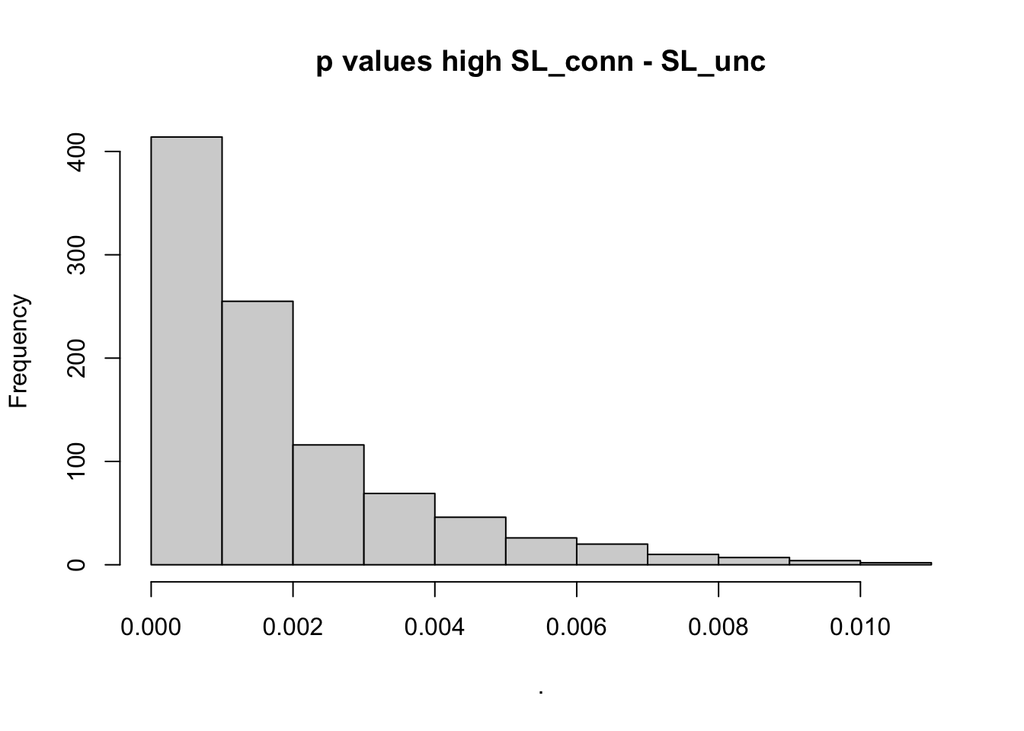

```r
results_table %>%
  filter(contrast == "high SL_conn - SL_unc") %>%
  pull(p.value) %>%
  hist(main = "p values high SL_conn - SL_unc")
```

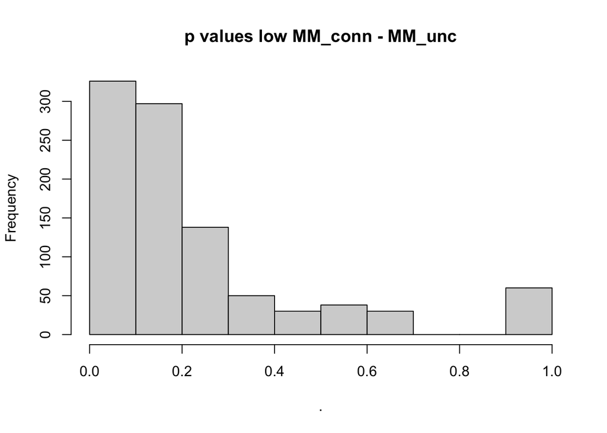

```r
results_table %>%
  filter(contrast == "low MM_conn - MM_unc") %>%
  pull(p.value) %>%
  hist(main = "p values low MM_conn - MM_unc")
```

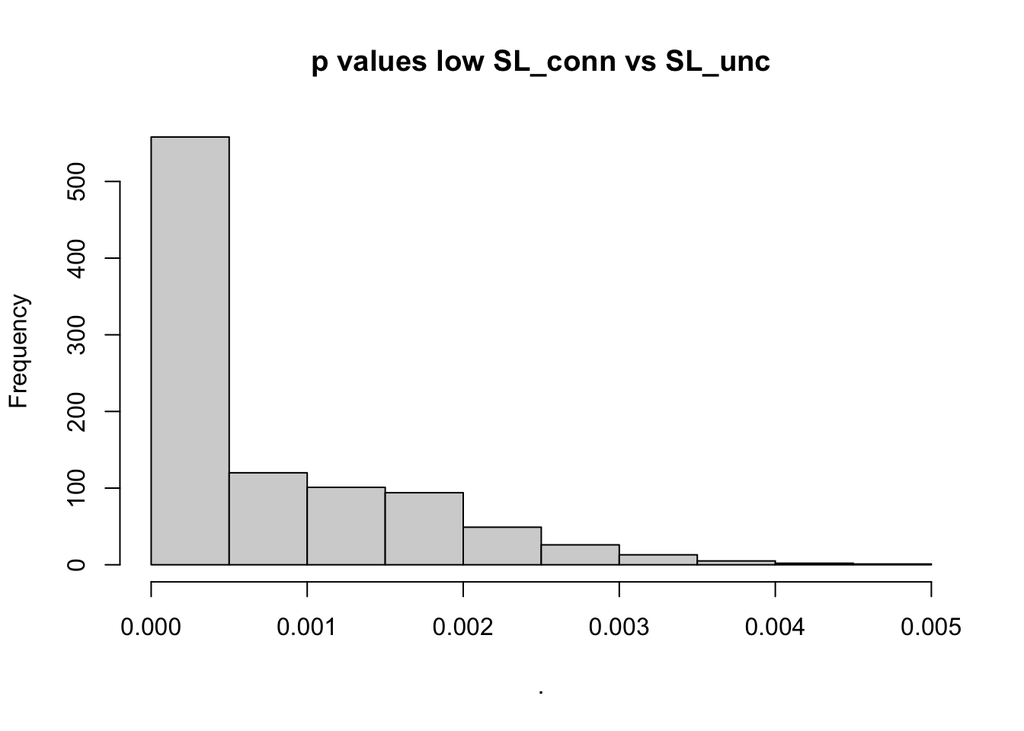

```r
results_table %>%
  filter(contrast == "low SL_conn - SL_unc") %>%
  pull(p.value) %>%
  hist(main = "p values low SL_conn vs SL_unc")
```

**Show iterated results - table with averaged values**

```r
# --- SHOW ITERATED RESULTS - TABLE WITH AVERAGED VALUES --- #

results_table %>%
  group_by(contrast) %>%
  summarise(estimate = median(estimate),
            SE = median(SE),
            df = median(df),
            t.ratio = median(t.ratio),
            p.value = median(p.value)) %>%
  as.data.frame() %>%
  mutate(estimate = round(estimate, digits = 3),
         SE = round(SE, digits = 3),
         df = round(df, digits = 3),
         t.ratio = round(t.ratio, digits = 3),
         p.value = round(p.value, digits = 3),
         evidence = "",
         evidence = ifelse(p.value > 0.1,
                           "none",
                           evidence),
         evidence = ifelse(p.value < 0.1,
                           "* weak",
                           evidence),
         evidence = ifelse(p.value < 0.05,
                           "** moderate",
                           evidence),
         evidence = ifelse(p.value < 0.01,
                           "*** strong",
                           evidence),
         evidence = ifelse(p.value < 0.001,
                           "**** very strong",
                           evidence),
         p.value = ifelse(p.value < 0.001,
                          "< 0.001",
                          p.value))
```

```
##                contrast estimate    SE     df t.ratio p.value         evidence
## 1 high MM_conn - MM_unc    0.064 0.045 44.803   1.377   0.174             none
## 2 high SL_conn - SL_unc   -0.124 0.036 44.803  -3.407   0.001       *** strong
## 3  low MM_conn - MM_unc    0.065 0.045 44.803   1.432   0.157             none
## 4  low SL_conn - SL_unc   -0.129 0.034 44.803  -3.800 < 0.001 **** very strong
```

### γ-Diversity

```r
response_variable_selected = "metaecosystem_richness"
```

**Plot original data - means**

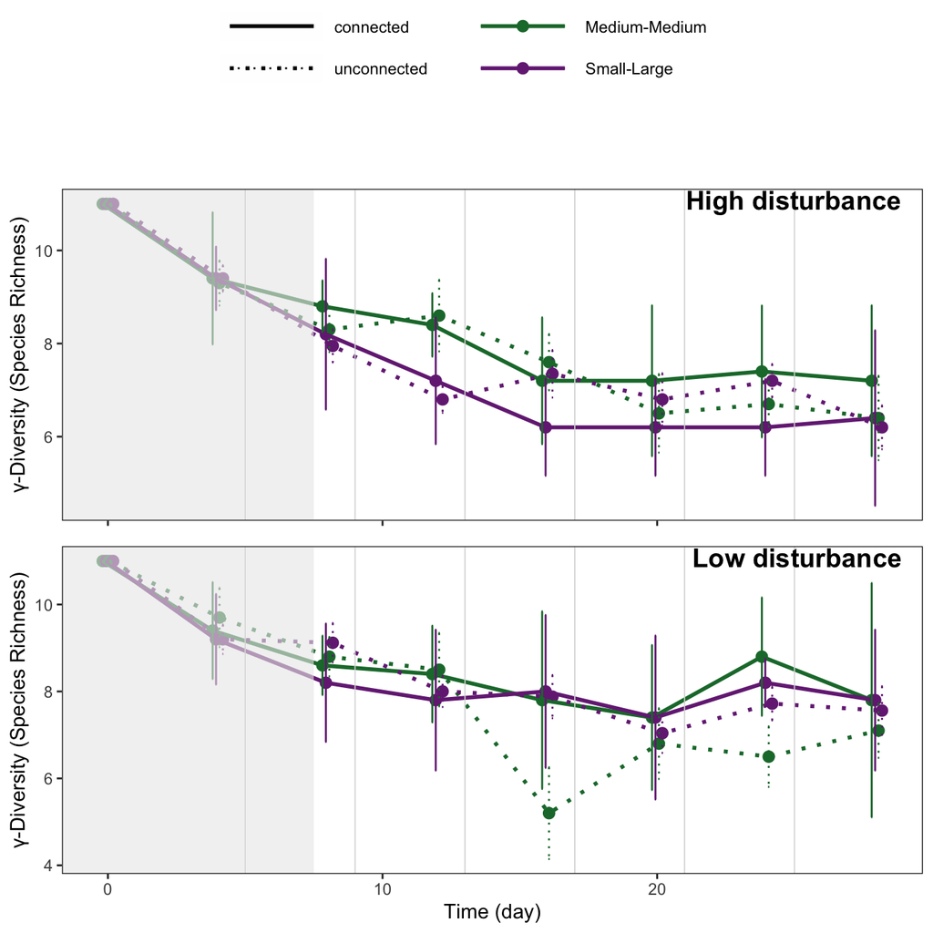

```r
# --- ORIGINAL DATA - PLOT MEAN ± 95% CI --- #

# Create plots

p1=plot.metaecos.points(ds_metaecosystems %>% filter(disturbance == "high"),
                        metaecosystem_type_selected,
                        response_variable_selected) +
  annotate("text",
           x = Inf,
           y = Inf,
           label = "High disturbance",
           hjust = 1.1,
           vjust = 1.1,
           size = 5,
           fontface = "bold") + # Adjust position and style
  theme(axis.title.x = element_blank(),  # Remove x-axis title
        axis.text.x = element_blank())  # Remove x-axis text

p2=plot.metaecos.points(ds_metaecosystems %>% filter(disturbance == "low"),
                        metaecosystem_type_selected,
                        response_variable_selected) +
  theme(legend.position = "none") +
  annotate("text",
           x = Inf,
           y = Inf,
           label = "Low disturbance",
           hjust = 1.1,
           vjust = 1.1,
           size = 5,
           fontface = "bold") # Adjust position and style

# Arrange the plots vertically

ggarrange(p1,
          p2,
          ncol = 1,
          nrow = 2,
          heights = c(0.9, 1),
          common.legend = TRUE,
          align = "v")
```

**Plot original data - single replicates**

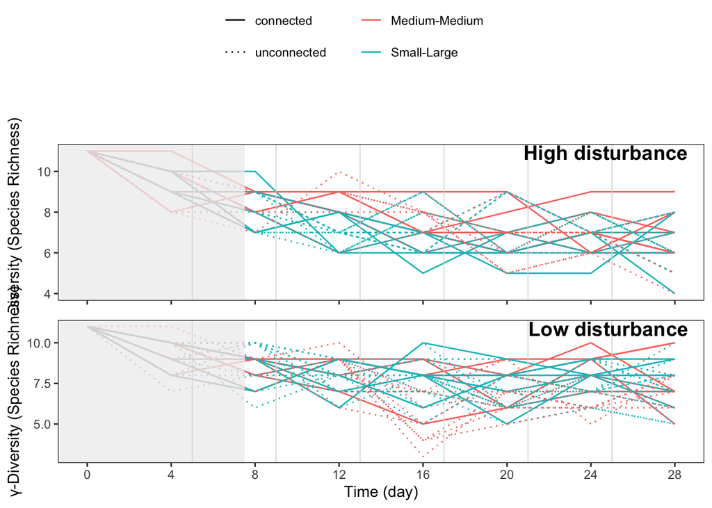

```r
# --- ORIGINAL DATA - PLOT SINGLE REPLICATES --- #

p1=plot.metaecos.replicates(ds_metaecosystems %>% filter(disturbance == "high"),
                            metaecosystem_type_selected,
                            response_variable_selected) +
  annotate("text",
           x = Inf,
           y = Inf,
           label = "High disturbance",
           hjust = 1.1,
           vjust = 1.1,
           size = 5,
           fontface = "bold") + # Adjust position and style
  theme(axis.title.x = element_blank(),  # Remove x-axis title
        axis.text.x = element_blank())  # Remove x-axis text

p2=plot.metaecos.replicates(ds_metaecosystems %>% filter(disturbance == "low"),
                            metaecosystem_type_selected,
                            response_variable_selected) +
  theme(legend.position = "none") +
  annotate("text",
           x = Inf,
           y = Inf,
           label = "Low disturbance",
           hjust = 1.1,
           vjust = 1.1,
           size = 5,
           fontface = "bold") # Adjust position and style

# Arrange the plots vertically

ggarrange(p1,
          p2,
          ncol = 1,
          nrow = 2,
          heights = c(0.9, 1),
          common.legend = TRUE,
          align = "v")
```

**Prepare data for analysis**

```r
# --- PREPARE DATA --- #

# Add baselines

baselines = ds_metaecosystems %>%
  filter(time_point == time_point_of_baselines) %>%
  select(system_nr,
         all_of(response_variable_selected)) %>%
  rename(baseline = all_of(response_variable_selected))

data_for_analysis = ds_metaecosystems %>%
  left_join(baselines)

# Filter and change level names

data_for_analysis = data_for_analysis %>%
  filter(time_point %in% time_points_model,
         metaecosystem_type %in% metaecosystem_type_selected,
         #!is.na(total_water_addition_ml),
         !is.na(!!sym(response_variable_selected))) %>%
  mutate(metaecosystem_type = case_when(metaecosystem_type == "Small-Large unconnected" ~ "SL unc",
                                        metaecosystem_type == "Medium-Medium unconnected" ~ "MM unc",
                                        metaecosystem_type == "Small-Small meta-ecosystem" ~ "SS con",
                                        metaecosystem_type == "Medium-Medium meta-ecosystem" ~ "MM con",
                                        metaecosystem_type == "Large-Large meta-ecosystem" ~ "LL con",
                                        metaecosystem_type == "Small-Large meta-ecosystem" ~ "SL con",
                                        TRUE ~ metaecosystem_type),
         type_conn = paste(metaecosystem_type, connection))
```

**Plot data for analysis means**

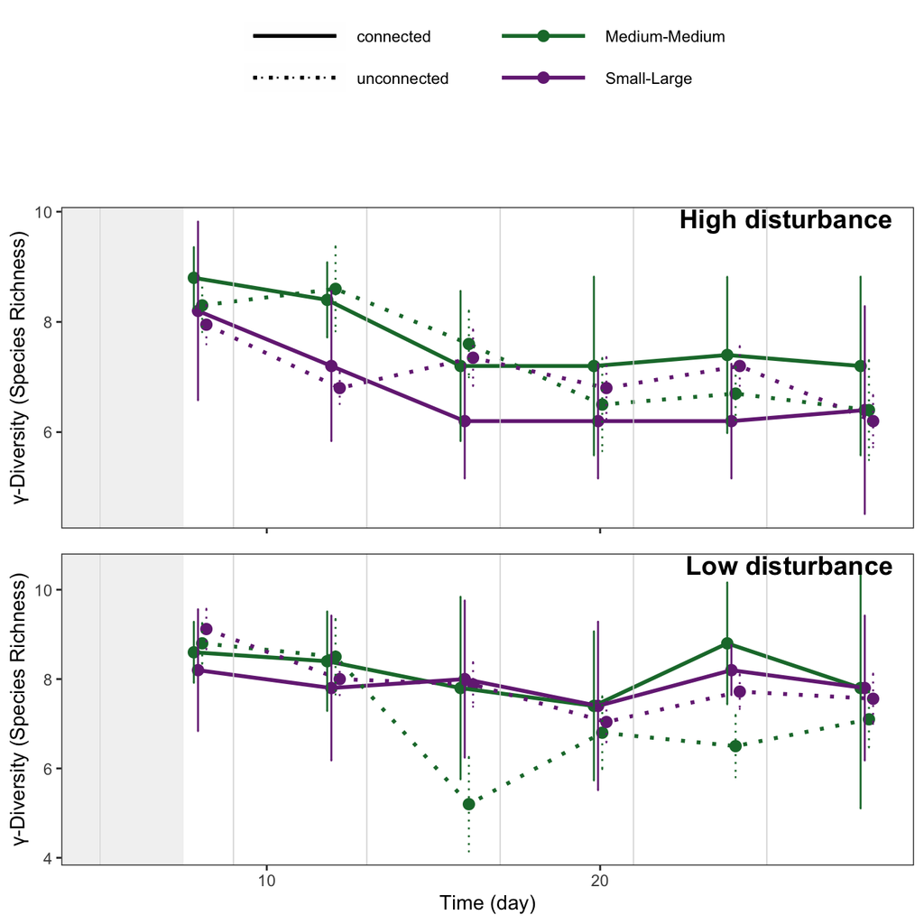

```r
# --- DATA FOR ANALYSIS - PLOT MEAN ± 95% CI OF FILTERED DATA --- #

p1=plot.metaecos.points(data_for_analysis %>% filter(disturbance == "high"),
                        metaecosystem_type_selected,
                        response_variable_selected) +
  annotate("text",
           x = Inf,
           y = Inf,
           label = "High disturbance",
           hjust = 1.1,
           vjust = 1.1,
           size = 5,
           fontface = "bold") + # Adjust position and style
  theme(axis.title.x = element_blank(),  # Remove x-axis title
        axis.text.x = element_blank())  # Remove x-axis text

p2=plot.metaecos.points(data_for_analysis %>% filter(disturbance == "low"),
                        metaecosystem_type_selected,
                        response_variable_selected) +
  theme(legend.position = "none") +
  annotate("text",
           x = Inf,
           y = Inf,
           label = "Low disturbance",
           hjust = 1.1,
           vjust = 1.1,
           size = 5,
           fontface = "bold") # Adjust position and style

# Arrange the plots vertically

ggarrange(p1,
          p2,
          ncol = 1,
          nrow = 2,
          heights = c(1, 0.7))
```

**Compute model results**

```r
# --- DEFINE MODEL FORMULA --- #

formula = paste("get(response_variable_selected) ~",
                "type_conn * disturbance * day +",
                "(day | baseline) +",
                "(day | system_nr)") %>%
  print()
```

```
## [1] "get(response_variable_selected) ~ type_conn * disturbance * day + (day | baseline) + (day | system_nr)"
```

```r
# --- FIND ECOSYSTEM COMBINATIONS FOR ANALYSIS --- #

# Set up parameters

bootstrap_iterations = 1000

# Produce random (bootstrapped) rows

random_sets_of_sets <- runif(bootstrap_iterations,
                             min = 1,
                             max = nrow(ecos_combin_unconn_sets_of_sets)) %>%
  round()

# Filter combinations according to the random rows

sets_of_sets_filtered = ecos_combin_unconn_sets_of_sets %>%
  filter(row_number() %in% random_sets_of_sets)
```

```r
# --- DEFINE WHERE TO SAVE (AND FROM WHERE TO LATER READ) THE RESULTS OF THE ANALYSIS --- #

file_path = here("..",
                 "3_results",
                 "tables",
                 paste0("results_metaeco_",
                        response_variable_selected,
                        "_",
                        bootstrap_iterations,
                        "_iterations",
                        ".csv"))
```

```r
# --- FIND MODEL STATISTICS THROUGH MULTIPLE ITERATIONS RESHUFFLING ECOSYSTEM COMBINATIONS --- #

# Set parameters and initialise

results_table = list()
failed_optimizers = 0

# Fit models

for (comb_i in 1:bootstrap_iterations) {

  # Find system numbers

  system_nr_unconn_selected = ecos_combin_unconn_sets %>%
    filter(metaecosystem_type == "Small-Large" &
           disturbance == "low" &
           set == sets_of_sets_filtered[comb_i, ]$set_SL_low |
           metaecosystem_type == "Small-Large" &
           disturbance == "high" &
           set == sets_of_sets_filtered[comb_i, ]$set_SL_high |
           metaecosystem_type == "Medium-Medium" &
           disturbance == "low" &
           set == sets_of_sets_filtered[comb_i, ]$set_MM_low |
           metaecosystem_type == "Medium-Medium" &
           disturbance == "high" &
           set == sets_of_sets_filtered[comb_i, ]$set_MM_high) %>%
    pull(system_nr)

  # Prepare data for analysis

  data_for_analysis_comb_i = data_for_analysis %>%
    filter(system_nr %in% system_nr_unconn_selected | connection == "connected")

  # Run model

  model = try.different.optimizers.metaecos(data_for_analysis_comb_i,
                                            formula)

  # If all the optimisers fail, move on to the next iteration

  if (is.null(model)) {
    cat("This model could not be fitted with any optimiser (",
        system_nr_unconn_selected,
        ") \n")

    failed_optimizers = failed_optimizers + 1

    next
  }

  # Residuals - show Q-Q plot

  # print(qqnorm(resid(model))); print(qqline(resid(model)))

  # Residuals - save Residuals vs Fitted plot

  # plot = data_for_analysis_comb_i %>%
  #     mutate(predicted = fitted(model),
  #            residuals = resid(model)) %>%
  #     ggplot(aes(x = predicted,
  #                y = residuals)) +
  #     geom_point()
  #
  # ggsave(here("3_results",
  #             "residual_plots",
  #               paste0("res_vs_fit_",
  #                      response_variable_selected,
  #                      "_combination_",
  #                      comb_i,
  #                      ".png")),
  #          plot = plot,
  #          width = 8,
  #          height = 6)

  # Set up contrasts

  emmeans_output = emmeans(model,
                           specs = ~ type_conn * day * disturbance ,
                           method = "pairwise",
                           adjust = "sidak",
                           bias.adj = TRUE,
                           lmer.df = "satterthwaite")

  summary(emmeans_output)

  zeros = rep(0, 8)
  high_MM_conn = zeros; high_MM_conn[1] = 1
  high_MM_unc = zeros; high_MM_unc[2] = 1
  high_SL_conn = zeros; high_SL_conn[3] = 1
  high_SL_unc = zeros; high_SL_unc[4] = 1
  low_MM_conn = zeros; low_MM_conn[5] = 1
  low_MM_unc = zeros; low_MM_unc[6] = 1
  low_SL_conn = zeros; low_SL_conn[7] = 1
  low_SL_unc = zeros; low_SL_unc[8] = 1

  # Save contrasts in a table

  results_table[[comb_i]] = contrast(
    emmeans_output,
    method = list("high SL_conn - SL_unc" = high_SL_conn - high_SL_unc,
                  "high MM_conn - MM_unc" = high_MM_conn - high_MM_unc,
                  "low SL_conn - SL_unc" = low_SL_conn - low_SL_unc,
                  "low MM_conn - MM_unc" = low_MM_conn - low_MM_unc)) %>%
    as.data.frame() %>%
    mutate(combination = comb_i,
           system_nr_unconnected_systems = paste(system_nr_unconn_selected, collapse = ", "))

}

# Tell how many optimizers failed

print(paste((failed_optimizers/bootstrap_iterations * 100),
            "% of combinations created models that could not be fit"))

# Bind rows within the list results_table

results_table = results_table %>%
  bind_rows()

# Save the results

write.csv(results_table,
          file = file_path,
          row.names = F)
```

```r
# --- READ THE RESULTS AFTER LENGTHY COMPUTATION --- #

results_table = read.csv(file = file_path)
```

**Show iterated results - p value distributions**

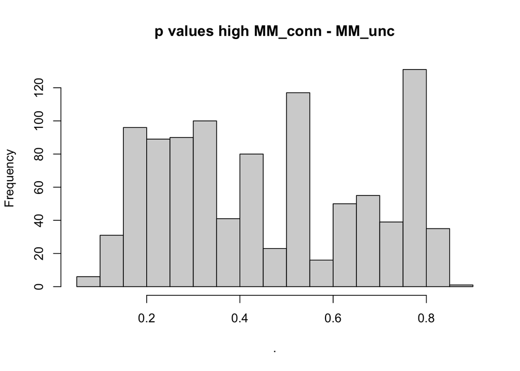

```r
# --- SHOW ITERATED RESULTS - P VALUE DISTRIBUTIONS --- #

results_table %>%
  filter(contrast == "high MM_conn - MM_unc") %>%
  pull(p.value) %>%
  hist(main = "p values high MM_conn - MM_unc")
```

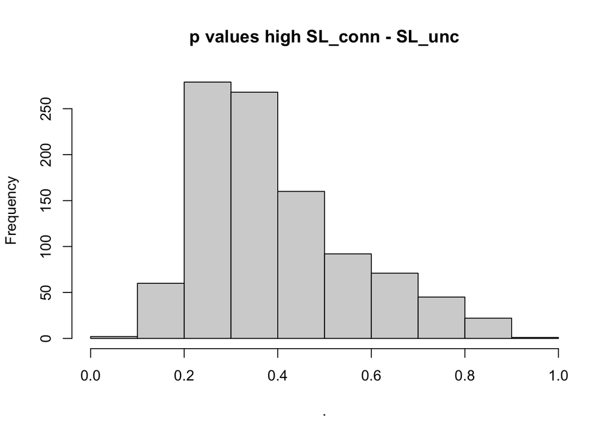

```r
results_table %>%
  filter(contrast == "high SL_conn - SL_unc") %>%
  pull(p.value) %>%
  hist(main = "p values high SL_conn - SL_unc")
```

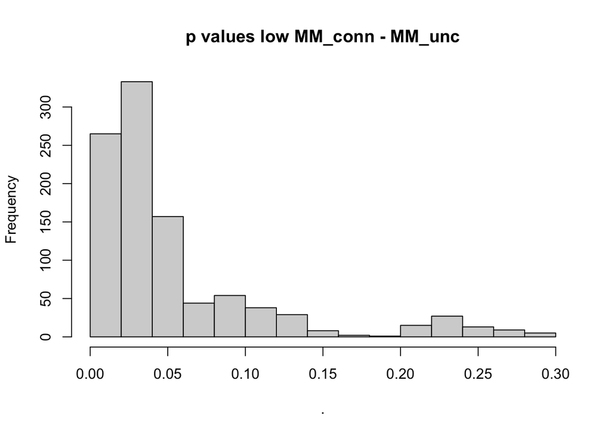

```r
results_table %>%
  filter(contrast == "low MM_conn - MM_unc") %>%
  pull(p.value) %>%
  hist(main = "p values low MM_conn - MM_unc")
```

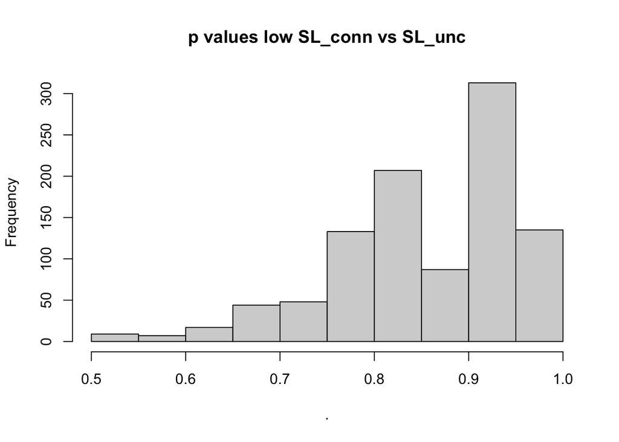

```r
results_table %>%
  filter(contrast == "low SL_conn - SL_unc") %>%
  pull(p.value) %>%
  hist(main = "p values low SL_conn vs SL_unc")
```

**Show iterated results - table with averaged values**

```r
# --- SHOW ITERATED RESULTS - TABLE WITH AVERAGED VALUES --- #

results_table %>%
  group_by(contrast) %>%
  summarise(estimate = median(estimate),
            SE = median(SE),
            df = median(df),
            t.ratio = median(t.ratio),
            p.value = median(p.value)) %>%
  as.data.frame() %>%
  mutate(estimate = round(estimate, digits = 3),
         SE = round(SE, digits = 3),
         df = round(df, digits = 3),
         t.ratio = round(t.ratio, digits = 3),
         p.value = round(p.value, digits = 3),
         evidence = "",
         evidence = ifelse(p.value > 0.1,
                           "none",
                           evidence),
         evidence = ifelse(p.value < 0.1,
                           "* weak",
                           evidence),
         evidence = ifelse(p.value < 0.05,
                           "** moderate",
                           evidence),
         evidence = ifelse(p.value < 0.01,
                           "*** strong",
                           evidence),
         evidence = ifelse(p.value < 0.001,
                           "**** very strong",
                           evidence),
         p.value = ifelse(p.value < 0.001,
                          "< 0.001",
                          p.value))
```

```
##                contrast estimate    SE     df t.ratio p.value    evidence
## 1 high MM_conn - MM_unc    0.367 0.442 39.171   0.822   0.416        none
## 2 high SL_conn - SL_unc   -0.339 0.353 38.411  -0.950   0.348        none
## 3  low MM_conn - MM_unc    0.967 0.445 39.581   2.173   0.036 ** moderate
## 4  low SL_conn - SL_unc    0.033 0.333 38.467   0.097   0.872        none
```

### Total Biomass

```r
response_variable_selected = "total_metaecosystem_bioarea_mm2"
```

**Plot original data - means**

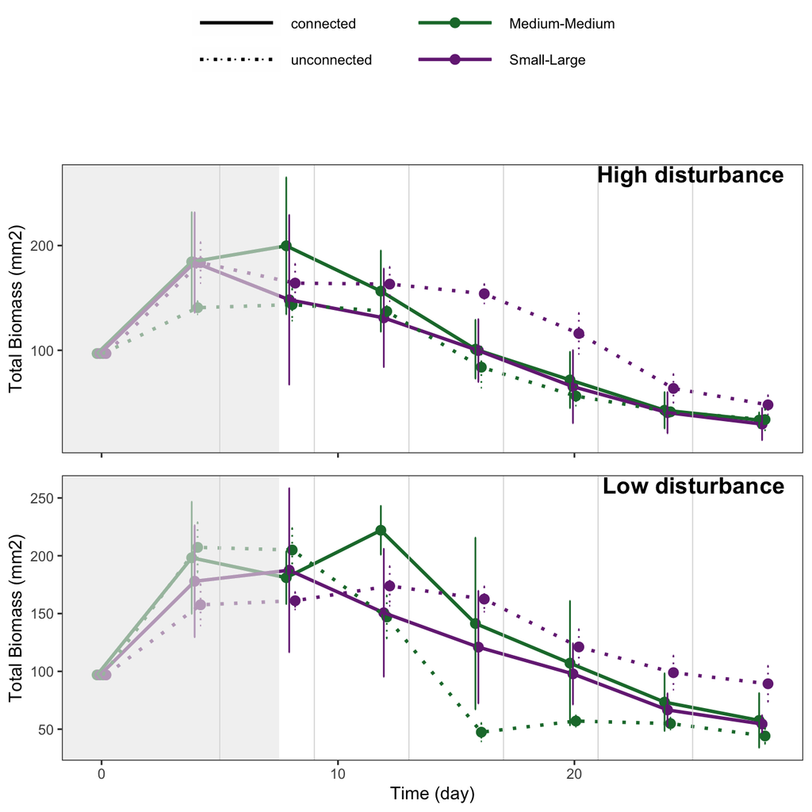

```r
# --- ORIGINAL DATA - PLOT MEAN ± 95% CI --- #

# Create plots

p1=plot.metaecos.points(ds_metaecosystems %>% filter(disturbance == "high"),
                        metaecosystem_type_selected,
                        response_variable_selected) +
  annotate("text",
           x = Inf,
           y = Inf,
           label = "High disturbance",
           hjust = 1.1,
           vjust = 1.1,
           size = 5,
           fontface = "bold") + # Adjust position and style
  theme(axis.title.x = element_blank(),  # Remove x-axis title
        axis.text.x = element_blank())  # Remove x-axis text

p2=plot.metaecos.points(ds_metaecosystems %>% filter(disturbance == "low"),
                        metaecosystem_type_selected,
                        response_variable_selected) +
  theme(legend.position = "none") +
  annotate("text",
           x = Inf,
           y = Inf,
           label = "Low disturbance",
           hjust = 1.1,
           vjust = 1.1,
           size = 5,
           fontface = "bold") # Adjust position and style

# Arrange the plots vertically

ggarrange(p1,
          p2,
          ncol = 1,
          nrow = 2,
          heights = c(0.9, 1),
          common.legend = TRUE,
          align = "v")
```

**Plot original data - single replicates**

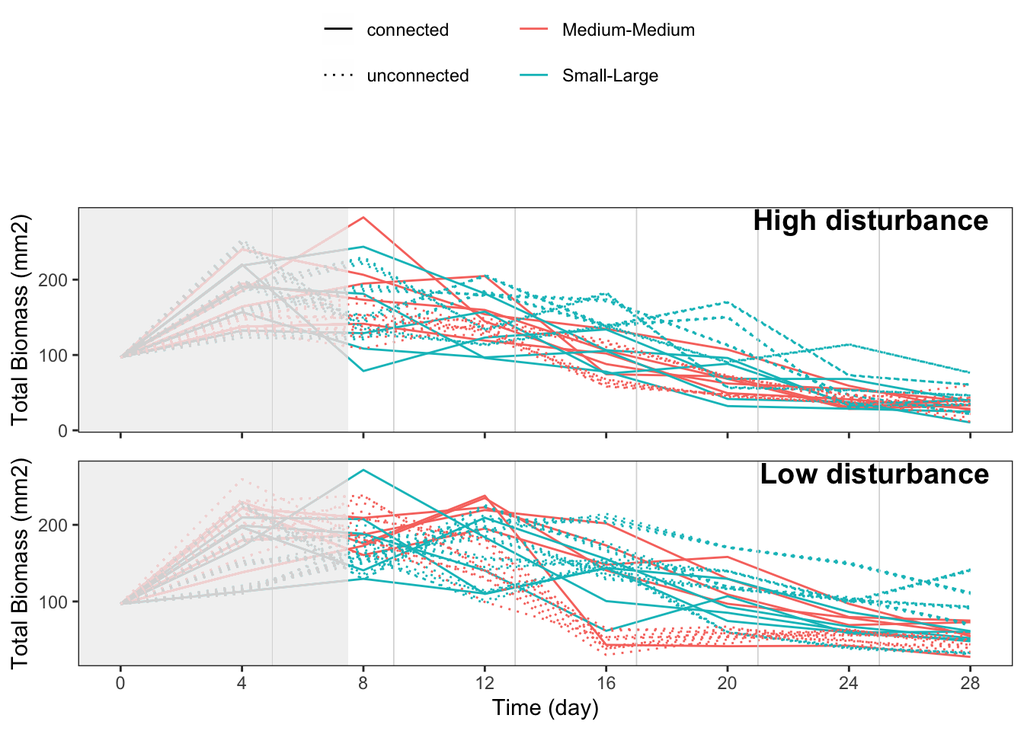

```r
# --- ORIGINAL DATA - PLOT SINGLE REPLICATES --- #

p1=plot.metaecos.replicates(ds_metaecosystems %>% filter(disturbance == "high"),
                            metaecosystem_type_selected,
                            response_variable_selected) +
  annotate("text",
           x = Inf,
           y = Inf,
           label = "High disturbance",
           hjust = 1.1,
           vjust = 1.1,
           size = 5,
           fontface = "bold") + # Adjust position and style
  theme(axis.title.x = element_blank(),  # Remove x-axis title
        axis.text.x = element_blank())  # Remove x-axis text

p2=plot.metaecos.replicates(ds_metaecosystems %>% filter(disturbance == "low"),
                            metaecosystem_type_selected,
                            response_variable_selected) +
  theme(legend.position = "none") +
  annotate("text",
           x = Inf,
           y = Inf,
           label = "Low disturbance",
           hjust = 1.1,
           vjust = 1.1,
           size = 5,
           fontface = "bold") # Adjust position and style

# Arrange the plots vertically

ggarrange(p1,
          p2,
          ncol = 1,
          nrow = 2,
          heights = c(0.9, 1),
          common.legend = TRUE,
          align = "v")
```

**Prepare data for analysis**

```r
# --- PREPARE DATA --- #

# Add baselines

baselines = ds_metaecosystems %>%
  filter(time_point == time_point_of_baselines) %>%
  select(system_nr,
         all_of(response_variable_selected)) %>%
  rename(baseline = all_of(response_variable_selected))

data_for_analysis = ds_metaecosystems %>%
  left_join(baselines)

# Filter and change level names

data_for_analysis = data_for_analysis %>%
  filter(time_point %in% time_points_model,
         metaecosystem_type %in% metaecosystem_type_selected,
         #!is.na(total_water_addition_ml),
         !is.na(!!sym(response_variable_selected))) %>%
  mutate(metaecosystem_type = case_when(metaecosystem_type == "Small-Large unconnected" ~ "SL unc",
                                        metaecosystem_type == "Medium-Medium unconnected" ~ "MM unc",
                                        metaecosystem_type == "Small-Small meta-ecosystem" ~ "SS con",
                                        metaecosystem_type == "Medium-Medium meta-ecosystem" ~ "MM con",
                                        metaecosystem_type == "Large-Large meta-ecosystem" ~ "LL con",
                                        metaecosystem_type == "Small-Large meta-ecosystem" ~ "SL con",
                                        TRUE ~ metaecosystem_type),
         type_conn = paste(metaecosystem_type, connection))
```

**Plot data for analysis means**

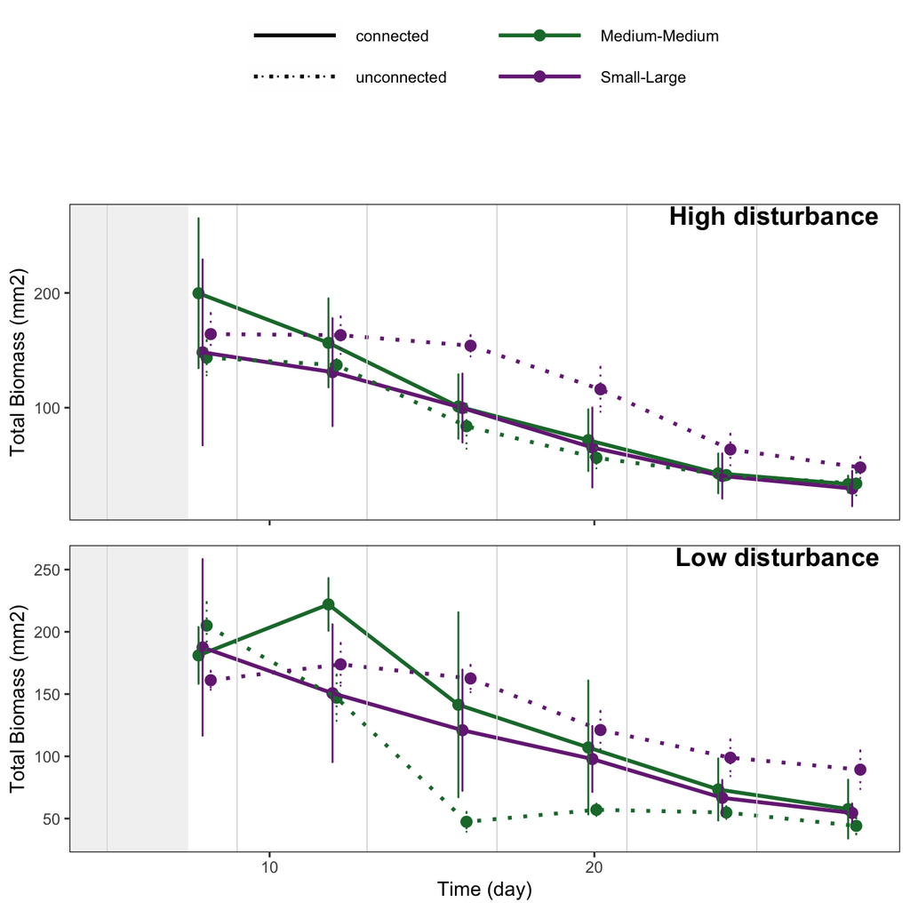

```r
# --- DATA FOR ANALYSIS - PLOT MEAN ± 95% CI OF FILTERED DATA --- #

p1=plot.metaecos.points(data_for_analysis %>% filter(disturbance == "high"),
                        metaecosystem_type_selected,
                        response_variable_selected) +
  annotate("text",
           x = Inf,
           y = Inf,
           label = "High disturbance",
           hjust = 1.1,
           vjust = 1.1,
           size = 5,
           fontface = "bold") + # Adjust position and style
  theme(axis.title.x = element_blank(),  # Remove x-axis title
        axis.text.x = element_blank())  # Remove x-axis text

p2=plot.metaecos.points(data_for_analysis %>% filter(disturbance == "low"),
                        metaecosystem_type_selected,
                        response_variable_selected) +
  theme(legend.position = "none") +
  annotate("text",
           x = Inf,
           y = Inf,
           label = "Low disturbance",
           hjust = 1.1,
           vjust = 1.1,
           size = 5,
           fontface = "bold") # Adjust position and style

# Arrange the plots vertically

ggarrange(p1,
          p2,
          ncol = 1,
          nrow = 2,
          heights = c(1, 0.7))
```

**Compute model results**

```r
# --- DEFINE MODEL FORMULA --- #

formula = paste("get(response_variable_selected) ~",
                "type_conn * disturbance * day +",
                "(day | baseline) +",
                "(day | system_nr)") %>%
  print()
```

```
## [1] "get(response_variable_selected) ~ type_conn * disturbance * day + (day | baseline) + (day | system_nr)"
```

```r
# --- FIND ECOSYSTEM COMBINATIONS FOR ANALYSIS --- #

# Set up parameters

bootstrap_iterations = 1000

# Produce random (bootstrapped) rows

random_sets_of_sets <- runif(bootstrap_iterations,
                             min = 1,
                             max = nrow(ecos_combin_unconn_sets_of_sets)) %>%
  round()

# Filter combinations according to the random rows

sets_of_sets_filtered = ecos_combin_unconn_sets_of_sets %>%
  filter(row_number() %in% random_sets_of_sets)
```

```r
# --- DEFINE WHERE TO SAVE (AND FROM WHERE TO LATER READ) THE RESULTS OF THE ANALYSIS --- #

file_path = here("..",
                 "3_results",
                 "tables",
                 paste0("results_metaeco_",
                        response_variable_selected,
                        "_",
                        bootstrap_iterations,
                        "_iterations",
                        ".csv"))
```

```r
# --- FIND MODEL STATISTICS THROUGH MULTIPLE ITERATIONS RESHUFFLING ECOSYSTEM COMBINATIONS --- #

# Set parameters and initialise

results_table = list()
failed_optimizers = 0

# Fit models

for (comb_i in 1:bootstrap_iterations) {

  # Find system numbers

  system_nr_unconn_selected = ecos_combin_unconn_sets %>%
    filter(metaecosystem_type == "Small-Large" &
           disturbance == "low" &
           set == sets_of_sets_filtered[comb_i, ]$set_SL_low |
           metaecosystem_type == "Small-Large" &
           disturbance == "high" &
           set == sets_of_sets_filtered[comb_i, ]$set_SL_high |
           metaecosystem_type == "Medium-Medium" &
           disturbance == "low" &
           set == sets_of_sets_filtered[comb_i, ]$set_MM_low |
           metaecosystem_type == "Medium-Medium" &
           disturbance == "high" &
           set == sets_of_sets_filtered[comb_i, ]$set_MM_high) %>%
    pull(system_nr)

  # Prepare data for analysis

  data_for_analysis_comb_i = data_for_analysis %>%
    filter(system_nr %in% system_nr_unconn_selected | connection == "connected")

  # Run model

  model = try.different.optimizers.metaecos(data_for_analysis_comb_i,
                                            formula)

  # If all the optimisers fail, move on to the next iteration

  if (is.null(model)) {
    cat("This model could not be fitted with any optimiser (",
        system_nr_unconn_selected,
        ") \n")

    failed_optimizers = failed_optimizers + 1

    next
  }

  # Residuals - show Q-Q plot

  # print(qqnorm(resid(model))); print(qqline(resid(model)))

  # Residuals - save Residuals vs Fitted plot

  # plot = data_for_analysis_comb_i %>%
  #     mutate(predicted = fitted(model),
  #            residuals = resid(model)) %>%
  #     ggplot(aes(x = predicted,
  #                y = residuals)) +
  #     geom_point()
  #
  # ggsave(here("3_results",
  #             "residual_plots",
  #               paste0("res_vs_fit_",
  #                      response_variable_selected,
  #                      "_combination_",
  #                      comb_i,
  #                      ".png")),
  #          plot = plot,
  #          width = 8,
  #          height = 6)

  # Set up contrasts

  emmeans_output = emmeans(model,
                           specs = ~ type_conn * day * disturbance ,
                           method = "pairwise",
                           adjust = "sidak",
                           bias.adj = TRUE,
                           lmer.df = "satterthwaite")

  summary(emmeans_output)

  zeros = rep(0, 8)
  high_MM_conn = zeros; high_MM_conn[1] = 1
  high_MM_unc = zeros; high_MM_unc[2] = 1
  high_SL_conn = zeros; high_SL_conn[3] = 1
  high_SL_unc = zeros; high_SL_unc[4] = 1
  low_MM_conn = zeros; low_MM_conn[5] = 1
  low_MM_unc = zeros; low_MM_unc[6] = 1
  low_SL_conn = zeros; low_SL_conn[7] = 1
  low_SL_unc = zeros; low_SL_unc[8] = 1

  # Save contrasts in a table

  results_table[[comb_i]] = contrast(
    emmeans_output,
    method = list("high SL_conn - SL_unc" = high_SL_conn - high_SL_unc,
                  "high MM_conn - MM_unc" = high_MM_conn - high_MM_unc,
                  "low SL_conn - SL_unc" = low_SL_conn - low_SL_unc,
                  "low MM_conn - MM_unc" = low_MM_conn - low_MM_unc)) %>%
    as.data.frame() %>%
    mutate(combination = comb_i,
           system_nr_unconnected_systems = paste(system_nr_unconn_selected, collapse = ", "))

}

# Tell how many optimizers failed

print(paste((failed_optimizers/bootstrap_iterations * 100),
            "% of combinations created models that could not be fit"))

# Bind rows within the list results_table

results_table = results_table %>%
  bind_rows()

# Save the results

write.csv(results_table,
          file = file_path,
          row.names = F)
```

```r
# --- READ THE RESULTS AFTER LENGTHY COMPUTATION --- #

results_table = read.csv(file = file_path)
```

**Show iterated results - p value distributions**

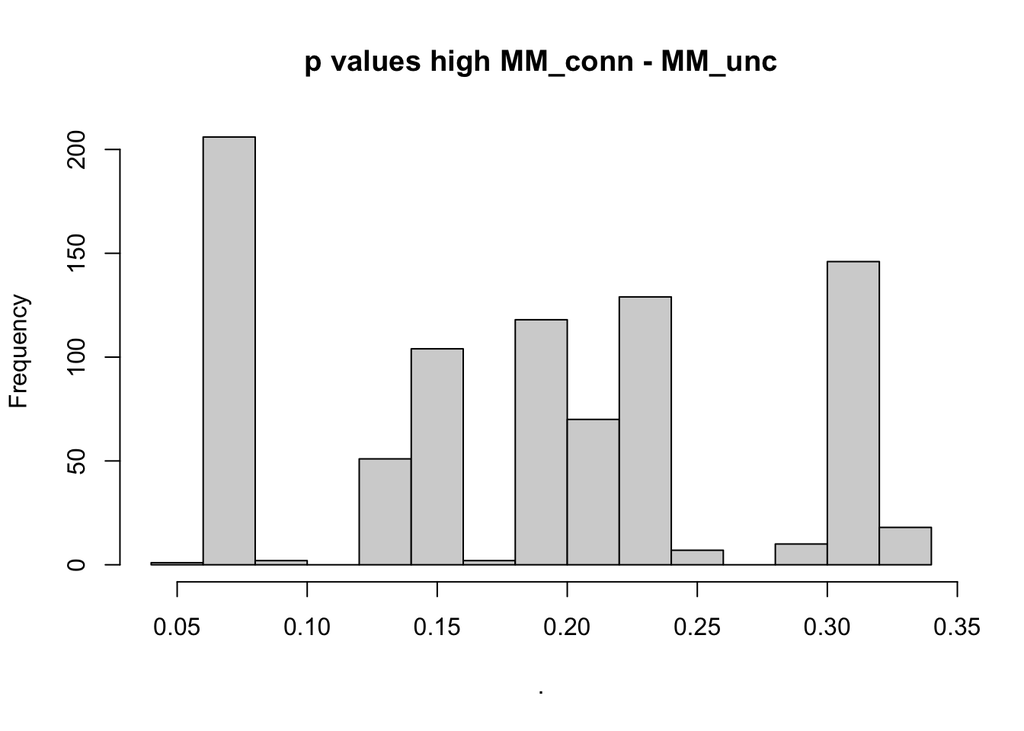

```r
# --- SHOW ITERATED RESULTS - P VALUE DISTRIBUTIONS --- #

results_table %>%
  filter(contrast == "high MM_conn - MM_unc") %>%
  pull(p.value) %>%
  hist(main = "p values high MM_conn - MM_unc")
```

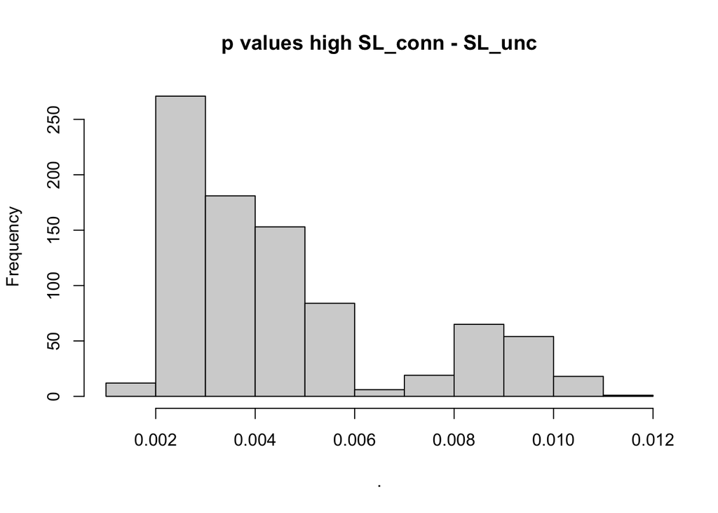

```r
results_table %>%
  filter(contrast == "high SL_conn - SL_unc") %>%
  pull(p.value) %>%
  hist(main = "p values high SL_conn - SL_unc")
```

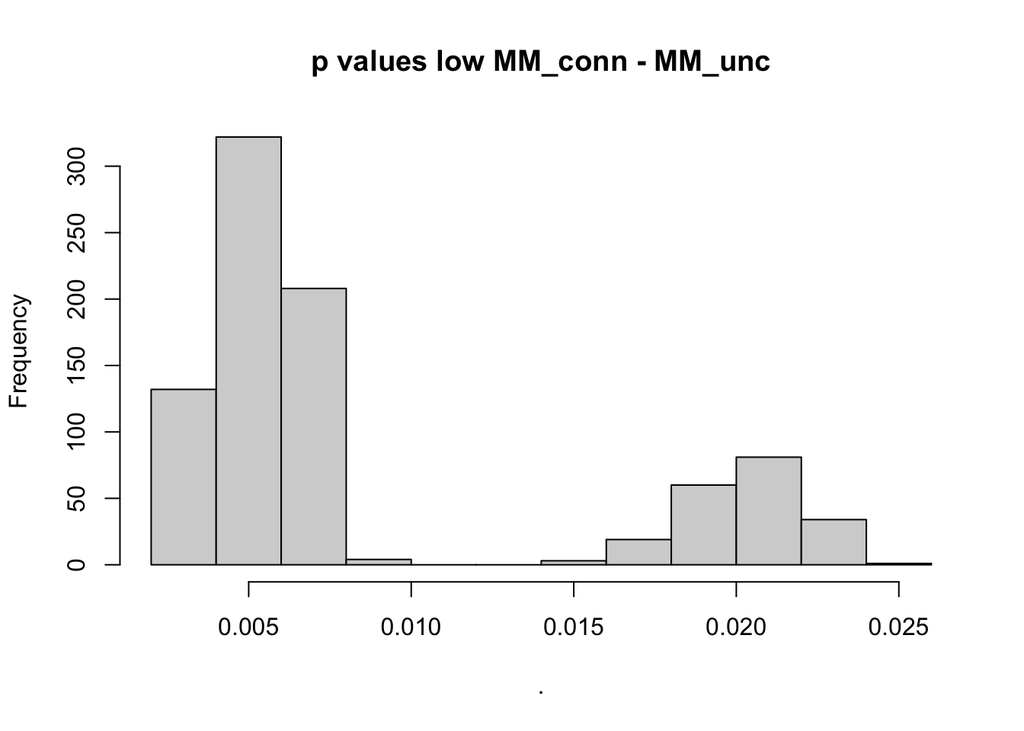

```r
results_table %>%
  filter(contrast == "low MM_conn - MM_unc") %>%
  pull(p.value) %>%
  hist(main = "p values low MM_conn - MM_unc")
```

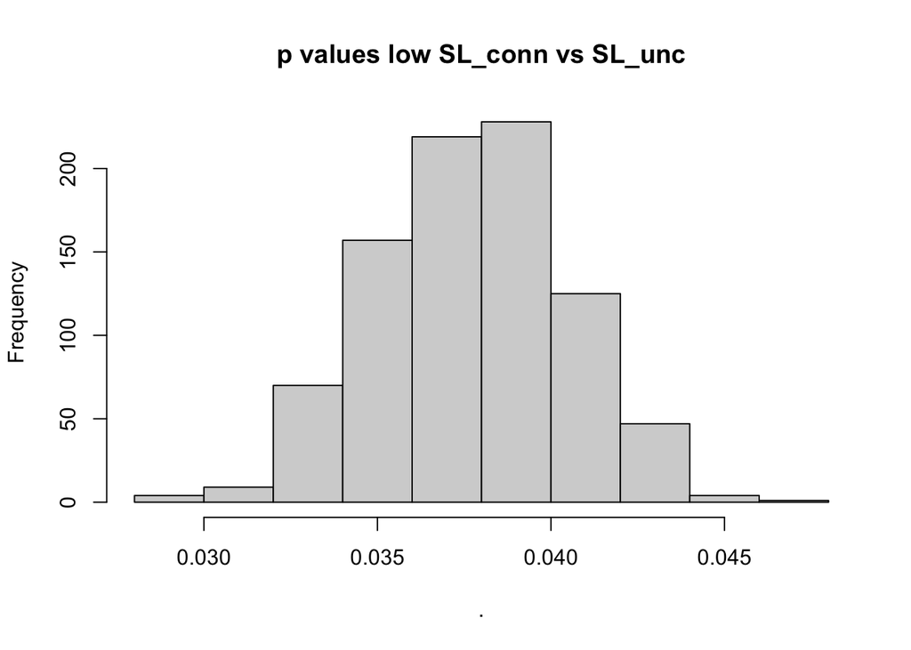

```r
results_table %>%
  filter(contrast == "low SL_conn - SL_unc") %>%
  pull(p.value) %>%
  hist(main = "p values low SL_conn vs SL_unc")
```

**Show iterated results - table with averaged values**

```r
# --- SHOW ITERATED RESULTS - TABLE WITH AVERAGED VALUES --- #

results_table %>%
  group_by(contrast) %>%
  summarise(estimate = median(estimate),
            SE = median(SE),
            df = median(df),
            t.ratio = median(t.ratio),
            p.value = median(p.value)) %>%
  as.data.frame() %>%
  mutate(estimate = round(estimate, digits = 3),
         SE = round(SE, digits = 3),
         df = round(df, digits = 3),
         t.ratio = round(t.ratio, digits = 3),
         p.value = round(p.value, digits = 3),
         evidence = "",
         evidence = ifelse(p.value > 0.1,
                           "none",
                           evidence),
         evidence = ifelse(p.value < 0.1,
                           "* weak",
                           evidence),
         evidence = ifelse(p.value < 0.05,
                           "** moderate",
                           evidence),
         evidence = ifelse(p.value < 0.01,
                           "*** strong",
                           evidence),
         evidence = ifelse(p.value < 0.001,
                           "**** very strong",
                           evidence),
         p.value = ifelse(p.value < 0.001,
                          "< 0.001",
                          p.value))
```

```
##                contrast estimate     SE     df t.ratio p.value    evidence
## 1 high MM_conn - MM_unc   17.326 13.109 33.314   1.325   0.194        none
## 2 high SL_conn - SL_unc  -32.905 10.510 33.314  -3.106   0.004  *** strong
## 3  low MM_conn - MM_unc   38.759 13.109 33.314   2.945   0.006  *** strong
## 4  low SL_conn - SL_unc  -21.448  9.909 33.314  -2.164   0.038 ** moderate
```

## Ecosystems analysis

### Shannon

```r
response_variable_selected = "shannon"
```

**Plot original data**

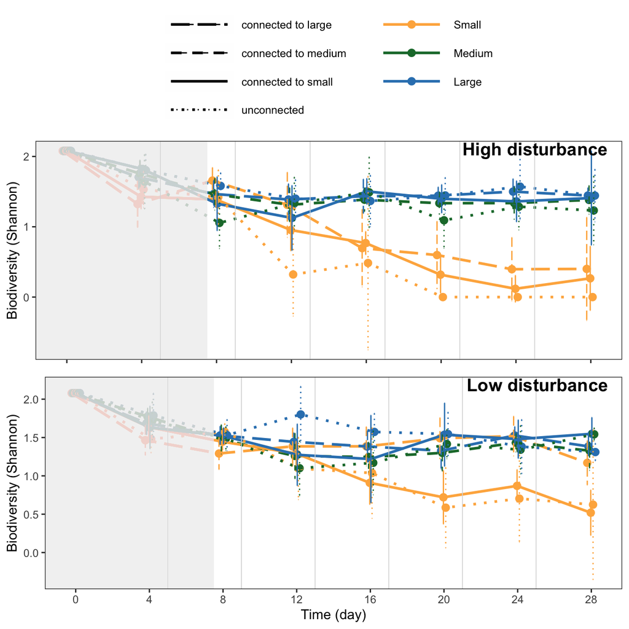

```r
# --- ORIGINAL DATA - PLOT MEAN ± 95% CI --- #

p1 = plot.all.patches.points(data = ds_ecosystems %>%
                               filter(disturbance == "high"),
                             response_variable_selected) +
  annotate("text",
           x = Inf,
           y = Inf,
           label = "High disturbance",
           hjust = 1.1,
           vjust = 1.1,
           size = 5,
           fontface = "bold") + # Adjust position and style
  theme(axis.title.x = element_blank(),  # Remove x-axis title
        axis.text.x = element_blank())  # Remove x-axis text
p2 = plot.all.patches.points(data = ds_ecosystems %>%
                               filter(disturbance == "low"),
                             response_variable_selected) +
  theme(legend.position = "none") +
  annotate("text",
           x = Inf,
           y = Inf,
           label = "Low disturbance",
           hjust = 1.1,
           vjust = 1.1,
           size = 5,
           fontface = "bold") # Adjust position and style

# Arrange the plots vertically

ggarrange(p1,
          p2,
          ncol = 1,
          nrow = 2,
          heights = c(1, 0.7))
```

**Prepare data for analysis**

```r
# --- PREPARE DATA FOR ANALYSIS --- #

# Add baselines

baselines = ds_ecosystems %>%
  filter(time_point == time_point_of_baselines) %>%
  select(ecosystem_ID,
         all_of(response_variable_selected)) %>%
  rename(baseline = all_of(response_variable_selected))

data_for_analysis = ds_ecosystems %>%
  left_join(baselines)

# Filter data and change level names

data_for_analysis = data_for_analysis %>%
  filter(time_point %in% time_points_model,
         #!is.na(water_addition_ml),
         !is.na(!!sym(response_variable_selected)),
         !is.infinite(!!sym(response_variable_selected))) %>%
  mutate(ecosystem_type = case_when(ecosystem_type == "Small unconnected" ~ "S",
                                    ecosystem_type == "Medium unconnected" ~ "M",
                                    ecosystem_type == "Large unconnected" ~ "L",
                                    ecosystem_type == "Small connected to small" ~ "S_S",
                                    ecosystem_type == "Small connected to large" ~ "S_L",
                                    ecosystem_type == "Medium connected to medium" ~ "M_M",
                                    ecosystem_type == "Large connected to large" ~ "L_L",
                                    ecosystem_type == "Large connected to small" ~ "L_S",
                                    TRUE ~ ecosystem_type)) %>%
  ungroup()
```

**Plot data for analysis means**

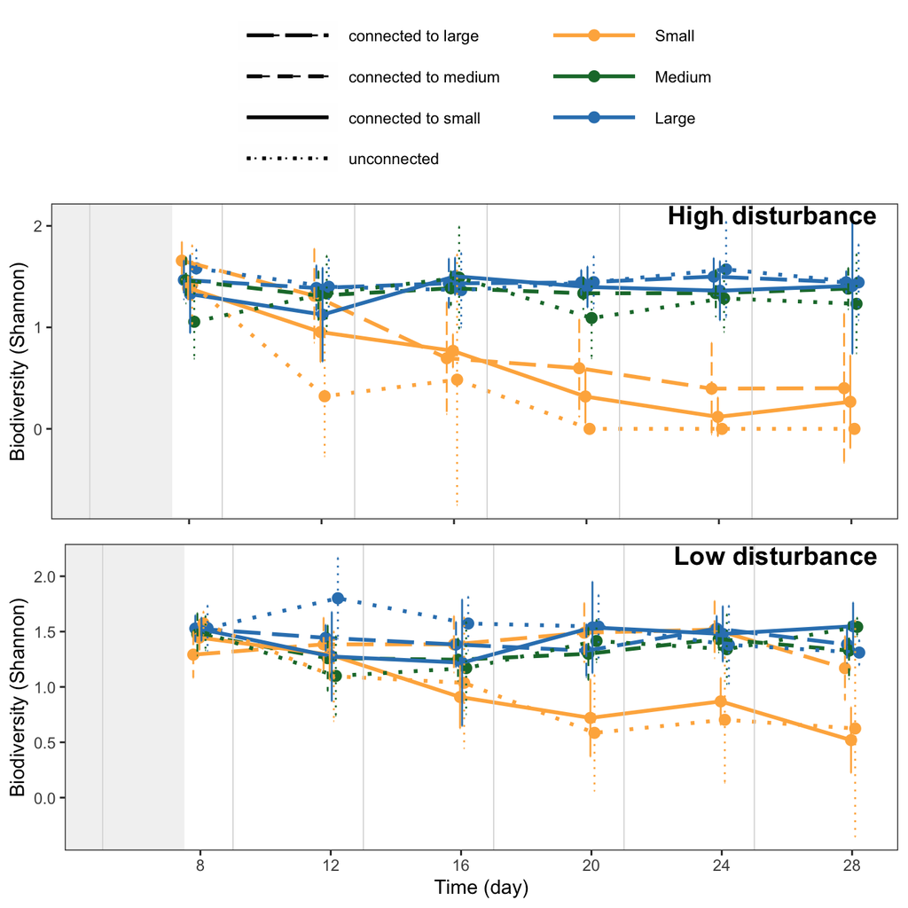

```r
# --- DATA FOR ANALYSIS - PLOT MEAN ± 95% CI --- #

p1 = plot.all.patches.points(data = data_for_analysis %>%
                               filter(disturbance == "high"),
                             response_variable_selected) +
  annotate("text",
           x = Inf,
           y = Inf,
           label = "High disturbance",
           hjust = 1.1,
           vjust = 1.1,
           size = 5,
           fontface = "bold") + # Adjust position and style
  theme(axis.title.x = element_blank(),  # Remove x-axis title
        axis.text.x = element_blank())  # Remove x-axis text
p2 = plot.all.patches.points(data = data_for_analysis %>%
                               filter(disturbance == "low"),
                             response_variable_selected) +
  theme(legend.position = "none") +
  annotate("text",
           x = Inf,
           y = Inf,
           label = "Low disturbance",
           hjust = 1.1,
           vjust = 1.1,
           size = 5,
           fontface = "bold") # Adjust position and style

# Arrange the plots vertically

ggarrange(p1,
          p2,
          ncol = 1,
          nrow = 2,
          heights = c(1, 0.7))
```

**Compute model results**

```r
# --- MODEL - CONSTRUCT --- #

# Define formula

formula = paste("get(response_variable_selected) ~",
                "ecosystem_type * disturbance * day +",
                "(day | ecosystem_ID) +",
                "(day | baseline)") %>%
  print()
```

```
## [1] "get(response_variable_selected) ~ ecosystem_type * disturbance * day + (day | ecosystem_ID) + (day | baseline)"
```

```r
# Construct model

model = try.different.optimizers.ecos(data_for_analysis,
                                      formula)
```

```
## [1] "Model successfully fitted with optimizer: bobyqa "
```

```r
# --- MODEL - SUMMARY --- #

print(summary(model), digits = 1)
```

```
## Linear mixed model fit by maximum likelihood . t-tests use Satterthwaite's
##   method [lmerModLmerTest]
## Formula: formula
##    Data: data
## Control: lmerControl(optimizer = opt$optimizer)
##
##       AIC       BIC    logLik -2*log(L)  df.resid
##     352.4     526.4    -137.2     274.4       602
##
## Scaled residuals:
##    Min     1Q Median     3Q    Max
##   -3.5   -0.6    0.0    0.7    3.7
##
## Random effects:
##  Groups       Name        Variance Std.Dev. Corr
##  ecosystem_ID (Intercept) 9e-09    1e-04
##               day         5e-11    7e-06    -1.00
##  baseline     (Intercept) 0e+00    0e+00
##               day         3e-18    2e-09     NaN
##  Residual                 9e-02    3e-01
## Number of obs: 641, groups:  ecosystem_ID, 109; baseline, 109
##
## Fixed effects:
##                                      Estimate Std. Error     df t value
## (Intercept)                             1e+00      2e-01  6e+02     9.6
## ecosystem_typeL_L                      -6e-02      2e-01  6e+02    -0.3
## ecosystem_typeL_S                      -3e-01      2e-01  6e+02    -1.2
## ecosystem_typeM                        -3e-01      2e-01  6e+02    -1.3
## ecosystem_typeM_M                      -6e-02      2e-01  6e+02    -0.3
## ecosystem_typeS                         1e-01      2e-01  6e+02     0.6
## ecosystem_typeS_L                       5e-01      2e-01  6e+02     2.5
## ecosystem_typeS_S                       3e-01      2e-01  6e+02     1.7
## disturbancelow                          4e-01      2e-01  6e+02     1.6
## day                                    -7e-04      8e-03  6e+02    -0.1
## ecosystem_typeL_L:disturbancelow       -3e-01      3e-01  6e+02    -1.0
## ecosystem_typeL_S:disturbancelow       -3e-01      3e-01  6e+02    -0.9
## ecosystem_typeM:disturbancelow         -4e-01      3e-01  6e+02    -1.2
## ecosystem_typeM_M:disturbancelow       -4e-01      3e-01  6e+02    -1.5
## ecosystem_typeS:disturbancelow         -2e-01      3e-01  6e+02    -0.6
## ecosystem_typeS_L:disturbancelow       -1e+00      3e-01  6e+02    -3.2
```

[output cut: 36 more lines]

```
## ecosystem_typeM:day                     0.781
## ecosystem_typeM_M:day                   0.836
## ecosystem_typeS:day                     4e-07 ***
## ecosystem_typeS_L:day                   2e-08 ***
## ecosystem_typeS_S:day                   2e-10 ***
## disturbancelow:day                      0.149
## ecosystem_typeL_L:disturbancelow:day    0.429
## ecosystem_typeL_S:disturbancelow:day    0.295
## ecosystem_typeM:disturbancelow:day      0.155
## ecosystem_typeM_M:disturbancelow:day    0.196
## ecosystem_typeS:disturbancelow:day      0.022 *
## ecosystem_typeS_L:disturbancelow:day    6e-07 ***
## ecosystem_typeS_S:disturbancelow:day    0.005 **
## ---
## Signif. codes:  0 '***' 0.001 '**' 0.01 '*' 0.05 '.' 0.1 ' ' 1
```

```
## optimizer (bobyqa) convergence code: 0 (OK)
## boundary (singular) fit: see help('isSingular')
```

```r
# --- MODEL - ANOVA --- #

car::Anova(model, type = "III")
```

```
## Analysis of Deviance Table (Type III Wald chisquare tests)
##
## Response: get(response_variable_selected)
##                                   Chisq Df Pr(>Chisq)
## (Intercept)                     92.1969  1  < 2.2e-16 ***
## ecosystem_type                  26.7429  7  0.0003707 ***
## disturbance                      2.5795  1  0.1082569
## day                              0.0077  1  0.9302887
## ecosystem_type:disturbance      11.9786  7  0.1012636
## ecosystem_type:day             155.7994  7  < 2.2e-16 ***
## disturbance:day                  2.0906  1  0.1482065
## ecosystem_type:disturbance:day  37.7566  7  3.371e-06 ***
## ---
## Signif. codes:  0 '***' 0.001 '**' 0.01 '*' 0.05 '.' 0.1 ' ' 1
```

```r
# --- ESTIMATE MARGINAL MEANS --- #

emmeans_output = emmeans(model,
                         specs = ~ ecosystem_type * disturbance * day,
                         adjust = "sidak",
                         bias.adj = TRUE,
                         lmer.df = "satterthwaite")

emmeans_output
```

```
##  ecosystem_type disturbance  day emmean     SE  df lower.CL upper.CL
##  L              high        17.8  1.468 0.0547 641    1.306    1.630
##  L_L            high        17.8  1.446 0.0387 641    1.331    1.560
##  L_S            high        17.8  1.353 0.0547 641    1.191    1.515
##  M              high        17.8  1.248 0.0547 641    1.086    1.410
##  M_M            high        17.8  1.370 0.0387 641    1.255    1.484
##  S              high        17.8  0.336 0.0736 641    0.118    0.554
##  S_L            high        17.8  0.854 0.0547 641    0.692    1.016
##  S_S            high        17.8  0.621 0.0412 641    0.499    0.743
##  L              low         17.8  1.526 0.0547 641    1.364    1.688
##  L_L            low         17.8  1.433 0.0387 641    1.318    1.547
##  L_S            low         17.8  1.429 0.0547 641    1.267    1.591
##  M              low         17.8  1.341 0.0547 641    1.179    1.503
##  M_M            low         17.8  1.341 0.0387 641    1.226    1.455
##  S              low         17.8  0.939 0.0557 641    0.774    1.104
##  S_L            low         17.8  1.373 0.0547 641    1.211    1.535
##  S_S            low         17.8  0.966 0.0387 641    0.852    1.081
##
## Degrees-of-freedom method: satterthwaite
## Results are given on the get (not the response) scale.
## Confidence level used: 0.95
## Conf-level adjustment: sidak method for 16 estimates
```

```r
# --- CODE EACH LEVEL OF DISTURBANCE AND ECOSYSTEM TYPE TO THEN PRODUCE CONTRASTS --- #

high_L = c(1, rep(0,15))
high_L_L = c(rep(0,1), 1, rep(0,14))
high_L_S = c(rep(0,2), 1, rep(0,13))
high_M = c(rep(0,3), 1, rep(0,12))
high_M_M = c(rep(0,4), 1, rep(0,11))
high_S = c(rep(0,5), 1, rep(0,10))
high_S_L = c(rep(0,6), 1, rep(0,9))
high_S_S = c(rep(0,7), 1, rep(0,8))
low_L = c(rep(0,8), 1, rep(0,7))
low_L_L = c(rep(0,9), 1, rep(0,6))
low_L_S = c(rep(0,10), 1, rep(0,5))
low_M = c(rep(0,11), 1, rep(0,4))
low_M_M = c(rep(0,12), 1, rep(0,3))
low_S = c(rep(0,13), 1, rep(0,2))
low_S_L = c(rep(0,14), 1, rep(0,1))
low_S_S = c(rep(0,15), 1)
```